# [2019]_ФЕДОРОВАГ.П._РазВнедАдПрогОбОтрНапр

```python
import os;import math;import sys;import datetime;
var='\\Untitled_0-10.ipynb'
print (var,':',os.path.getsize(os.path.abspath(os.curdir)+var)/math.pow(2, 20),' мегобайт ',datetime.datetime.now())
#http://localhost:8888/notebooks/Untitled1.ipynb
#print("http://localhost:8888/notebooks/Untitled1.ipynb")
```

```
\Untitled_0-10.ipynb : 0.04372978210449219  мегобайт  2025-04-28 18:30:21.178759
```

[2019]_ФЕДОРОВАГ.П._РазВнедАдПрогОбОтрНапр

СРЕДНЕЕ ПРОФЕССИОНАЛЬНОЕ ОБРАЗОВАНИЕ  
Г.Н. Федорова

# РАЗРАБОТКА, ВНЕДРЕНИЕ И АДАПТАЦИЯ ПРОГРАММНОГО ОБЕСПЕЧЕНИЯ ОТРАСЛЕВОЙ НАПРАВЛЕННОСТИ

УЧЕБНОЕ ПОСОБИЕ

Стр. 0

СРЕДНЕЕ ПРОФЕССИОНАЛЬНОЕ ОБРАЗОВАНИЕ  
Г.П. ФЕДОРОВА

# РАЗРАБОТКА, ВНЕДРЕНИЕ И АДАПТАЦИЯ ПРОГРАММНОГО ОБЕСПЕЧЕНИЯ ОТРАСЛЕВОЙ НАПРАВЛЕННОСТИ

УЧЕБНОЕ ПОСОБИЕ  
Рекомендовано в качестве учебного пособия для учебных заведений, реализующих программу среднего профессионального образования по специальности 2.09.02.05 Прикладная информатика (по отраслям). ИМ "Разработка, внедрение и адаптация программного обеспечения отраслевой направленности)  
Москва КУРС ИНФРА-М 2019

Стр. 1

УДК 6813.06(075.8)  
ББК 32.973-018.2  
ФЗЗ

Рецензенты:  
Л.А. Ибрагимова - доктор педагогических наук, профессор, ФГ БОУ НПО " Нидневар товский государственный университет".  
В. В. Кузьмин — кандидат технических наук, доцент, директор филиала ФГБОУ ВО СГАСУ в г. Белебее РБ.

Г.Н. Федорова  
Разработка, внедрение и адаптация программного обеспечения отраслевой направленности: Учебное пособие / Г.Н. Федорова. - М. : КУРС : ИНФРА-М, 2019. - 336 с. (Среднее профессиональное образование).

В учебном пособии рассматривается круг вопросов, связанных с разработкой, внедрением и адаптацией программного обеспечения. Излагаются методы отладки, и тестирования программ, и особенности разработки технической и проектной документации. Анализируются методики измерений характеристик программного обеспечения, оценки их эффективности, описываются стандарты качества программного обеспечения. Обсуждаются технологии сбора информации и создания информационных ресурсов. Учебное пособие подготовлено для студентов учреждений среднего профессионального образования по специальности 2.09.02.05 — Прикладная информатика (по отраслям) по профессиональному модулю «Разработка, внедрение и адаптация программного обеспечения отраслевой направленности» и полностью соответствует Федеральному Государственному образовательному стандарту СПО по данной специальности.

УДК 681.3.06(075.8)  
ББК 32.973’018.2

ISBN 978-5-906818-41-6 (КУРС)  
ISBN 978-5-16-01 \876-5 (И НФРА-M. print)  
ISBN 978-5-16-104356-1 (ИНФРА-M. online)

Стр. 2

# Предисловие

Учебные издания по информатизации производства и управления теряют свою актуальность в короткие сроки, так как стремительно меняются и информационные технологии, используемые на предприятиях. и экономические условия, в которых они работают. При этом подготовка в среднем учебном заведении предусматривает овладение будущими специалистами самыми новейшими знаниями в области разработки и внедрения программного обеспечения и умением активно использовать эти знания в своей профессиональной деятельности. Предлагаемое учебное пособие не претендует на полномасштабное изложение материала по созданию отраслевых программных продуктов. Эта книга дает широкое представление о технологиях разработки программного обеспечения, процессах взаимодействия компонентов программных систем, особенностях решения тех или иных прикладных задач на различных программных платформах. Углубленно рассматриваются лишь некоторые наиболее важные аспекты разработки, тестирования, обеспечения надежности программного обеспечения. Для получения более подробных разъяснений к предлагаемому материалу следует обратиться к литературе, список которой приводится в конце книги.

Главы 1—4 посвящены вопросам технологии разработки программного обеспечения. В них рассматривается жизненный цикл программного обеспечения, излагаются стратегии разработки программного обеспечения (каскадная, инкрементная, эволюционная), даются сравнительные характеристики и описываются поддерживающие их процессы. Разъясняются методы проведения обследования предметной области, составления функциональных и эксплуатационных спецификаций по требованиям заказчика. Даются раъяснения по основам объектно-ориентированного программирования. В главе 5 рассматриваются вопросы, связанные с тестированием программного обеспечения — проверкой соответствия программного обеспечения требованиям. Особое внимание уделено тестированию производительности программного обеспечения — нагрузочному тестированию, тестированию стабильности и другим видам тестирования.

Глава 6 содержит материалы по стандартизации и документированию разработки программного обеспечения. В ней сформулированы основные задачи и принципы стандартизации, рассмотрены основные нормативные документы по с тандартизации государственные стандарты РФ, международные (региональные) стандарты, правила, нормы и рекомендации по стандартизации, общероссийские классификаторы и т.д. Часть материалов посвящена рассмотрению вопросов документирования программного обеспечения в соответствии с российскими стандартами. Дается общее описание стандартов ЕСПД и ГОСТ Р.

Стр. 3

Представленные стандарты регламентируют процессы ли шенного цикла, описывают характеристики программного обеспечения, регламентируют составление технического задания на разработку программной) обеспечения, документации пользователя и других программных и эксплуатационных документов. Главы 7-11 посвящены разработке и администрированию баз данных. Без знаний в области данных невозможна разработка программного обеспечения. В указанных главах рассматриваются типовые модели логической организации данных, механизмы проектирования баз данных, основные методы и средства защиты данных, возможности языка SQL для работы с базами данных. Изложены вопросы обеспечения целостности данных, принципы и технологии обмена данными в компьютерных сетях. В главах 12-15 излагаются основные принципы разработки интернет-приложение. Эти главы учебного издания охватывают достаточно широкий спектр технологий и подходов, используемых в web-разработке. Описываются способы реализации клиентской активности. Отдельная глава посвящена способам организации активных web-серверов, формированию динамических документов HTMLc помощью CGI, языков Perl, PHP. Рассматриваются приложения ISAPI и их использование для формирования динамических документов. Рассказывается о среде ASP и ASP.NET. Главы 16, 17 посвящены вопросам обеспечения качества программного продукта и способам повышения его надежности. В этих главах описываются способы количественной оценки процесса разработки программного обеспечения, а именно, методы сбора, анализа и использования метрик и моделей измерения. Много внимания уделяется и вопросам обеспечения надежности программного продукта на различных этапах разработки, а также анализу рисков, возникающих в процессе его создания.

Глава 18 посвящена информационным системам на предприятии. В ней достаточно подробно раскрыты положения и методологические принципы современных информационных систем управления, а также и тожена стратегия их развития. Проанализированы принципы построения итерированных корпоративных информационных систем. Учебное пособие подготовлено в полном соответствии с Федеральным Государственным образовательным стандартом СПО, может быть испольювано студентами при освоении профессионального модуля «Разработка, внедрение и адаптация программного обеспечения отраслевой направленности»специальности 09.02.05 Прикладная информатика (по отраслям). Предлагаемый материал может стать полезным для студентов и преподавателей других специальностей, связанных с программным обеспечением, а также для широкого круга специалистов, занимающихся разработкой и внедрением программных продуктов на предприятиях.

Стр. 4

# Глава I. ЖИЗНЕННЫЙ НИКЛ ПРОГРАММНОГО ОБЕСПЕЧЕНИЯ

## 1.1. Основные термины и определения

Программное обеспечение (ПО) представляет собой совокупность программ и сопровождающей их документации, обеспечивающую решение прикладных задач и функционирование аппаратных средств ЭВМ. В каждой отрасли есть специфические бизнеспроцессы, требования и задачи. Для решения задач, специфичных для какой-либо отдельной отрасли, разрабатывается и используемся отраслевое программное обеспечение, которое нацелено на максимальное соответствие потребностям в автоматизации важных для предприятий бизнес-процессов. **Бизнес-процесс** - это совокупность взаимосвязанных действии или операций, которые используют ресурсы предприятия для создания или получения продукции (работ, услуг), необходимой потрсбителю. Технологияра работки программного обеспечения представляет собой совокупность методик, методологий и средств, обеспечивающих в заданных условиях получение программной продукции с заданными свойствами. Технология разработки программного обеспечении охватывает содержание процесса программирования в его широком значении - от появления потребности в создании некоторых программ до ее изготовления, передачи пользователю, модификации и процессе эксплуатации и прекращения использования вследствие моральною старения. Программное обеспечение обладает внутренней организацией, или внутренней структурой, образованной взаимосвязанными программными модулями. Это справедливо для сложных и многофункциональных программных продуктов, которые называются программными системами. Структурное разбиение программ на отдельные составляющие служит основой и для выбора инструментальных средств их создания, хотя имеет место и обратное влияние — выбор инструментальных средств разработчика программного обеспечения определяет типы программных модулей.

Стр. 5

При создании программных продуктов выделяются многократно используемые модули, проводится их типизация и унификация, засчет чего сокращаются сроки и трудозатраты на разработку программного продукта в целом. Некоторые программные продукты используют модули из готовых библиотек стандартных подпрограмм, процедур, функций, объектов, методов обработки данных. Информационная технология - это приемы, способы и методы применения средств вычислительной техники при выполнении функций сбора, хранения, обработки и использования данных. Любой программный продукт (ПП) должен выполнять те функ-ции, для которых был создан. Качественный ПП должен обладать еще рядом свойств, позволяющих успешно его использовать в течение продолжительного времени. Качество программного обеспечения — это совокупность его характеристик. которые влияют на способность программного обеспечения удовлетворять заданные потребности пользователя. Это. однако, не означает, что разные программные продукты должны обладать одним и тем же набором свойств с одинаковыми значениями количественных показателей. Как и в случае технических устройств, показатели качества являются противоречивыми, что означает следующее — улучшение одних показателей качества может быть достигнуто за счет ухудшения других. Качество программного обеспечения является удовлетворительным, если количественные показатели свойств гарантируют успешное его использование. Ниже дается описание основных критериев качества программного обеспечения.

Функциональность можно определить как способность программного обеспечения выполнять набор функций, определенных его внешними спецификациями. Надежностью называют способность программного обеспечения безотказно выполнять заданные функции при заданных условиях в течение заданного периода времени с высокой степенью вероятности. Надежность не означает безошибочности, для надежного программного обеспечения важно, чтобы ошибки появлялись при применении программного обеспечения достаточно редко и не приводили к катастрофическим последствиям. Легкость применения — это способность минимизировать затраты пользователя на подготовку и ввод исходных данных и оценку полученных результатов, а также вызывать положительные эмоции пользователя. Эффективность — это отношение уровня услуг, предоставляемых программным обеспечением, к объему используемых вычислительных ресурсов. Объем используемых вычислительных ресурсов количественно определяется затратами машинного времени и оперативной памяти на выполнение заданных функций.

Стр. 6

Мобильность программных продуктов означает их независимость от технического комплекса системы обработки данных, операционной среды, сетевой технологии обработки данных, специфики предметной области и т.п. Мобильный (многоплатформенный) программный продукт может быть установлен на различных моделях компьютеров и операционных систем, без ограничения на его экеплуатацию в условиях вычислительной сети. Модифицируемость npoграммного обеспечения означает способность к внесению изменений, например расширение функций обработки, переход на другую техническую базу обработки и г.л. Коммуникативность программного обеспечения основана на максимально возможной их интеграции с другими программами, обеспечении обмена данными (экспорт/импорт баз данных, внедрение или связывание объектов обработки и т.д.). Сопровождаемость программного обеспечения характеристики программного обеспечения, позволяющие минимизировать усилия по внесению в него изменений для устранения ошибок или для модификации в соответствии с изменяющимися потребностями пользователей. **Точность** - характеристика, определяющая точность результатов выполнения расчетов в соответствии с их назначением. Например, если в программе ведутся расчеты по банковским операциям, то разумная точность составляет три знака после запятой с последующим округлением до двух знаков. Если в программе производятся расчеты по биологическим экспериментам на молекулярном уровне, то может потребоваться точность до 10-12 десятичных знаков. Устойчивость к ошибкам предсказуемость работы про!раммного продукта в условиях любых наборов входных данных или наличия ошибок при взаимодействии с оборудованием.

**Информативность** — одна из характеристик, обеспечивающая понятность программного обеспечения. Говорят, что программный продукт обладает характеристикой информативности, если содержит информацию, обеспечивающую понимание назначения программного обеспечения, принятых ограничений, смыслового жачения результатов работы отдельных компонентов. Открытость программного обеспечения при доступности его исходного кода дает возможиость понять на жачение каждого оператора программного обеспечения (например, каждый из идеитификаторов программы должен нести смысловую нагрузку). Согласованность как характеристика качественного программного обеспечения бывает внутренней и внешней. Внутренняя согласованность должна обеспечивать единую терминологию, единую трактовку понятий и значений. Особое значение эта характеристика приобретаст при создании программных комплексов, когда над проектом работает группа специалистов, и в процессе работы необходимы контакты по взаимной увязке программных модулей. Внешняя согласонанность обеспечивается однозначным соответствием создаваемого программного обеспечения требованиям, изложенным в техническом проекте на его разработку, а также тем или иным отраслевым стандартам.

Стр. 7

# 1.2. Стадии жизненного цикла программного обеспечения

Понятие жизненного цикла является одним из базовых понятий методологии разработки программного обеспечения. Жизненный цикл программного обеспечения (ЖЦ НО) представляет собой непрерывный процесс, начинающийся с момента принятия решения о создании программного обеспечения и заканчивающийся в момент полного изъятия его из эксплуатации. Для того чтобы получить представление о возможной структуре жизненного цикла программного обеспечения, обратимся сначала к соответствующим стандартам, описывающим технологические процессы. Международным стандартом, регламентирующим жизненный цикл программного обеспечения, является ISO/IEC 12207 (ISO — International Standards Organization, Международная организация по стандартизации; IЕС — International Electrotechnical Commission, Международная комиссия по электротехнике). Стандарт ISO/IEC 12207 определяет структуру жизненного цикла, включая процессы, действия и задачи, которые должны быть выполнены во время создания программного продукта. Российским аналогом является ГОСТ Р ИСО/МЭК 12207 — Информационная технология. Системная и программная инженерия. Процессы жизненного цикла программных средств. Жизненный цикл программного обеспечения можно представить как ряд событий, происходящих с ПО в процессе его создания и использования. Разработка программного обеспечения, как правило, выполняется для определенной предметной области. Особенности предметной области и функционирования программного обеспечения в ней, безусловно, оказывают влияние на состав ПО. Программное обеспечение разрабатывается как некоторый проект. Многие особенности управления проектами и фазы разработки проекта (фазы жизненного цикла) являются общими, не зависящими не только от предметной области, но и от характера проекта. Каждый проект, независимо от сложности и объема работ, необходимых для его выполнения, проходит в своем развитии определенные состояния. Совокупность ступеней развития от возникновения идеи до полного завершения проекта принято разделять на стадии или этапы.

Стр. 8

В определении количества стадий и их содержании имеются некоторые отличия, поскольку эти характеристики во многом зависят от условий осуществления конкретного проекта и опыта основных участников. Тем нс менее логика и основное содержание процесса разработки информационной системы почти во всех случаях являются общими. Можно выделить следующие сталии развития программного обеспечения: первое, анализ предметной области и формирование требований (концепции) ; второе, проектирование; третье, реализация; четвертое, тестирование; пятое, ввод в эксплуатацию; шестое, эксплуатация (сопровождение проекта). Завершается жизненный цикл программного обеспечения выводом его из эксплуатации. Для каждого этапа определяются состав и последовательность выполняемых работ, получаемые результаты, методы и средства, необходимые для выполнения работ, роли и ответственность участников и т.д. Такое формальное описание ЖЦ программного продукта позволяет спланировать и организовать процесс коллективной разработки и обеспечить управление этим процессом. Рассмотрим каждую из стадий более подробно. Стадия формирования требований к программному обеспечению является одной из важнейших, поскольку определяет успех всего проекта. На этом этапе формулируются цели и задачи проекта, устанавливается область применения программного обеспечения и определяются граничные условия, выделяются базовые сущности и взаимосвязи между ними. Идентифицируются все внешние объекты, с которыми должно взаимодействовать разрабатываемое программное обеспечение, и определяется характер этого взаимодействия на высоком уровне, те. идеи зифинируются все функциональные возможности программ и производится описание наиболее существенных из них. Определяются сроки и стоимость разработки ПО, формируется и подписывается техническое задание на ра «работку программного обеспечения. Таким образом, создается основа для дальнейшего проектирования прозраммного продукта.

Стр. 9

Сталия анализа и формирования требонаний включает в себя следуюшие этапы: **Во первых** - планирование работ. Основными задачами этого этапа янляются: определение мелей разработки; предварительная экономическая опенка проекта; построение плана-графика выполнения работ. **Во вторых**, проведение обследования автоматизируемого объекта, в рамках которого осушествляются: предварительное определение требований к программному обеспечению; анализ информации, поступающей из внешних источников; анализ внутренних информационных потоков; построение моделей предметной области на основании результатов обследования. **В третьих**, анализ существующих аналогичных программных продуктов. Сталия проектирования, как правило, включает определение архидектуры программной системы, ее функций, внешних условий функционирования, интерфейсы и распределение функций между пользователями и системой, требования к программным и информационным компонентам. Проектирование системы проводится на основе результатов формирования требований. Методология проектирования соединяет в себе приемы представления физической, логической, а также динамической и статической моделей системы. Разрабатывается функциональная спецификация программного обеспечения, выбирается архитектура системы, определяется наиболее подходящая СУБД, проектируются структуры хранения данных. оговариваются требования к аппаратному обеспечению, определяется набор организационных мероприятий, которые необходимы для внедрения программного обеспечения, а также перечень документов, регламентирующих его использование. Оформляется эксплуатационная документация. '

На этапе реализации строятся прототипы как целой программной системы, так и ее частей, осуществляется физическая реализация структур данных, разрабатываются программные коды, выполняется отладочное тестирование, создается техническая документация. В результате этапа реализации появляется рабочая версия продукта. Тестирование программного продукта тесно связано с такими этапами разработки, как проектирование и реализация. В систему встраиваются специальные механизмы, которые дают возможность производить тестирование программного обеспечения на соответствие требований к нему, проверку оформления и наличия необходимого пакета документации. Результатом тестирования являются устранение всех недостатков программного продукта и заключение о ее качестве. Внедрение (ввод в эксплуатацию) программного обеспечения обычно предусматривает такие шаги, как: установка программной сие гемы; обучение пользователей; докумен гирование (выдача соответствующих приказов, приемочных актов и т.п.).

К любой разработке прилагается полный пикет документации, который включает в себя описание программного продукта, руководства пользователей и алгоритмы работы. Поддержка функционирования программною обеспечения должна осуществляться группой панической поддержки разработчика. Сопровождение что процесс адаптации поставляемого программного обеспечения к новым условиям, внесения изменений в программное обеспечение и соответст вующую документацию, вызванных возникшими проблемами или потребностями в модификации при сохранении неизменными его основных функций. Границы каждой стадии жизненного цикла иртраммного обеспечения определены некоторыми моментами времени, в которые необходимо принимать определенные критические решения и, следовательно, достигать определенных ключевых целей.

Стр. 10

# 1.3. Процессы жизненного цикла программного обеспечения

Международный стандарт ISO/IES 12207 определяет действия, которые могут быть выполнены на протяжении жизненного цикла программного обеспечения. Каждый процесс разделен на набор действий, каждое действие — на набор задач. В соответствии со стандартом структура жизненного цикла основывается на трех группах процессов: Во первых, основные процессы жизненного цикла (приобретение, поставка, разработка, эксплуатация, сопровождение). Во вторых, вспомогательные процессы, обеспечивающие выполнение основных процессов (документирование, управление конфигурацией, обеспечение качества, верификация, аттестация, оценка, аудит, разрешение проблем). В третьих, организационные процессы (управление проектами, создание инфраструктуры проекта, усовершенствование, обучение).

# Основные процессы жизненного цикла.

Выделяют пять основных процессов, жизненного цикла программного обеспечения. Каждый процесс характеризуется определенными задачами и методами их решения. исходными данными и результатами. Под основным участником процесса понимается сторона, которая инициирует или выполняет разработку, эксплуатацию или сопровождение программного изделия. Это покупатель, поставщик, разработчик, персонал эксплуатации и персонал сопровождения программных изделий. Процесс приобретения определяет действия предприятия-покупателя. которое приобретает программное обеспечение. Процесс поставки определяет действия предприятия-поставщика, которое снабжает покупателя информационной системой.

Стр. 11

Процесс разработки определяет действия предприятия-разработ чика, включает в себя стратегическое планирование, анализ, проектироване и реализацию (программирование), т.е. все работы по созданию информационного программного обеспечения и его компонентов в соответствии с заданными требованиями. Включает также оформление проектной и эксплуатационной документации, подготовку материалов, необходимых для тестирования разработанных программных продуктов и для обучения персонала. Разработка является одним из важнейших процессов жизненного цикла информационной системы. Процесс эксплуатации определяет действия персонала, обеспечивающие обслуживание информационной системы в процессе ее функционирования в интересах пользователей. Основные эксплуатационные работы включают непосредственно эксплуатацию, локализацию проблем и устранение причин их возникновения, модификацию программного обеспечения, подготовку предложений по совершенствованию системы, развитие и модернизацию системы. В процесс эксплуатации входят также конфигурирование базы данных и рабочих мест пользователей, обеспечение пользователей эксплуатационной документацией, обучение персонала. Процесс сопровождения определяет действия персонала, обеспечивающие сопровождение программною продукта. Сопровождение представляет собой управление модификациями программного продукта, поддержку его текущего состояния и функциональную пригодность и включает в себя инсталляцию и удаление программного обеспечения системы. В процессе сопровождения в программное обеспечение вносят необходимые изменения, которые могут потребовать пересмотра проектных решений, принятых на любом этапе жизненного цикла. Именно это и послужило причиной выделения этапа сопровождения в отдельный процесс жизненного цикла в соответствии со стандартом ISO/IES 12207.

# Вспомогательные процессы жизненного цикла.

Данные процессы поддерживают реализацию основных процессов, будучи неотъемлемой частью всего жизненного цикла информационной системы, с определенной целью и обеспечивают должное качество информационной системы. Вспомогательные процессы используются и выполняются по мере необходимости и инициируются другими процессами. Процесс документирования определяет действия для записи информации, являющейся результатом выполнения какого-либо процесса жизненного никла программного обеспечения. Процесс управления конфигурацией определяет действия по управлению конфигурацией. Это тот вспомогательный процесс, который поддерживает основные процессы жизненною никла информаниокном системы, прежде всего процессы разработки и сопровождении. При разработке проектов сложного программного обеспечения, состоящего из многих компонентов, каждый из которых может разрабатываться независимо и, следовательно, иметь несколько вариантов реализации и/или несколько версий одной реализации, возникает проблема учета их связей и функций, создания единой структуры и обеспечения развития всей системы. Управление конфигурацией позволяет организовывать, систематически учитывать и контролировать внесение изменений в различные компоненты информационной системы на всех стадиях ее жизненного цикла.

Стр. 12

Процесс обеспечения качества определяет действия для объективной гарантии того, что информационная система и процессы соответствуют определенным требованиям к ним и установленным замыслам. Совместная оценка, верификация, проверки, аттестации могут быть использованы как способы гарантии качества. Процесс верификации определяет действия (для покупателя, поставщика или независимой стороны).зля верификации программного обеспечения информационной системы с различной глубиной зависимости от проекта. Процесс аттестации определяет действия (покупателя, поставщика, независимой стороны) для аттестации программного обеспечения информационной системы. Процесс совместной оценки определяет действия для опенки состояния и результатов какого-либо действия. Этот процесс может быть использован любыми двумя сторонами, где одна сторона (проверяющая, рецензирующая) проверяет (рецензирует) другую сторону (проверяемую) на совместном форуме. Процесс проверки — это деятельность, направленная на определение соответствия требованиям, замыслам и контрактам. Этот процесс может быть использован любыми двумя сторонами, где одна сторона (проверяющая) проверяет программное обеспечение информационной системы или деятельность другой стороны (проверяемой). Процесс решения проблем определяет процесс анализа и устранения проблем (включая несоответствия), какова бы ни была их природа или источник, которые были обнаружены на протяжении разработки, эксплуатации, сопровождения или других процессов.

Стр. 13

# Организационные процессы.

Организационные процессы жизненного цикла выполняются какой-либо организацией с целью создания и обеспечения деятельности нижестоящей структуры, включающей в себя связанные процессы жизненного цикла и персонал, а также совершенствования структуры и процессов. Они. как правило, инвариантны относительно конкретных проектов и контрактов, однако уроки, извлеченные из таких проектов и контрактов, способствуют совершенствованию организации. Управление проектом связано с вопросами планирования и организации работ, создания коллективов разработчиков и контроля за сроками и качеством выполняемых работ. Техническое и организационное обеспечение проекта включает; выбор методов и инструментальных средств для реализации проекта; определение методов описания промежуточных состояний разработки; разработку методов и средств испытаний созданного профаммного обеспечения; обучение персонала.

Обеспечение качества проекта связано с проблемами верификации, проверки и тестирования компонентов информационной системы. **Процесс верификации** — это процесс определения соответствия текущего состояния разработки, достигнутого на данном этапе, требованиям этого этапа. Процесс создания инфраструктуры управления охватывает выбор и поддержку (сопровождение) технологии, стандартов и инструментальных средств, выбор и установку аппаратных и программных средств, используемых для разработки эксплуатации или сопровождения программного обеспечения ИС. Инфраструктура, в свою очередь, является одним из объектов управления конфигурацией. Процесс усовершенствования предусматривает оценку, измерение, контроль и усовершенствование процессов жизненного цикла. Усовершенствование процессов ЖЦ направлено на повышение производительности труда всех участвующих в них специалистов за счет совершенствования используемой технологии, методов управления, выбора инструментальных средств и обучения персонала. Усовершенствование основано на анализе достоинств и недостатков каждого процесса. Процесс обучения охватывает первоначальное обучение и последующее постоянное повышение квалификации персонала.

Стр. 14

# 1.4. Поставка и внедрение программного обеспечения

Для управления поставками программного обеспечения в организации. занимающейся разработкой программного обеспечения, должна быть определена процедура поставки программного обеспечения. Данная процедура разрабатывается и утверждается внутри каждой организации, занимающейся разработкой программного обеспечения, но в зависимости от требований заказчика она может быть модифицирована для какого-либо конкретного проекта. Процедура поставки программного продукта включает в себя перечень основных дейстрий и задач. которые должны быть выполнены в процессе постановки, с указанием их очередности. Версией программного продукта (version) называют экземпляр программного продукта, имеющий определенные отличия от других экземпляров этого же программного продукта. Новые версии могут отличаться функциональными возможностями, эффективностью либо отсутствием ошибок, имевшихся в старых версиях. Некоторые вереии различаются конфигурацией аппаратного или программного обеспечения, для которого они были разработаны, при этом обладая одинаковой функциональностью. Выходная версия (release) это та версия программного обеспечения, которая поставляется заказчику, т.е. является поставкой ПО. В каждой новой выходной версии либо присутствуют новые функциональные возможности, либо эта версия разработана для новой аппаратной платформы. Не все версии поставляются заказчику, а создаются для внутреннего пользования в процессе разработки программного обеспечения, поэтому количество версий, как правило, превышает количество поставок.

Каждая версия поставляемого программного обеспечения имеет свой определенный номер. Версия программного обеспечения нумеруется согласно схеме A.B.C.D, где: А — мажорная версия (major version) программного обеспечения; В - минорная версия (minor subversion, промежуточная версия) программного обеспечения; С — «релиз» (release) программного обеспечения; D — сборка (build) программного обеспечения. Также может использоваться простой номер программного обеспечения — А.

Стр. 15

Выпуск и внедрение новых версий программного обеспечения обусловлено разными причинами, например: необходимостью исправления ошибок, выявленных в процессе эксплуатации предыдущих версий; необходимостью совершенствования предыдущих версий, например улучшения интерфейса или расширения состава выполняемых функций; изменением среды функционирования, например появлением новых технических средств и/или программных продуктов. Готовое к поставке программное обеспечение должно быть классифицировано следующим обраюм: ES-поставка — поставка прототипа; РА-поставка — поставка альфа-версии; РВ-поставка — поставка бета-версии; RP-поставка — окончательная поставка. Прототип является начальной версией программного продукта, используемой для демонстрации концепций, заложенных в системе, проверки вариантов требований, а также поиска проблем, которые могут возникнуть как в ходе разработки, так и при эксплуатации ПП, и возможных вариантов их решения.

Альфа-версия программного обеспечения реализует все или практически все основные функции ПО, однако некоторые из них могут erne отсутствовать или выполняться с ошибками, возможно крайне нестабильно. Альфа-версию обычно отдают только заказчикам с целью обнаружения в ней дефектов на ранней стадии разработки продукта (но уже когда реализована вся или почти вся функциональность). В бета-версии реализован полный набор запланированных функций программного обеспечения. В отличие от альфа-версии использование бета-версии предполагает привлечение сторонних пользователей Фатальных ошибок в программном обеспечении нет, готовы все проектные документы, документация пользователя и программное обеспечение соответствуют требованиям заказчика. Это уже интенсивное использование почти готовой версии программного обеспечения с полным набором запланированныхфункций. Целью его явыявлется максимального числа ошибок в работе прорамное обеспечения для их последующего устранения перед окончательным выходом продукта на рынок, к массовому потребителю. Кроме того, бета-версия может использоваться в рекламных целях как часть стратегии продвижения продукта на рынок (например, бесплатная-версия бета-версий позволяет привлечь широкое внимание пользователей к окончательной дорогой версии продукта), а также для получения предварительных отзывов о нем от широкого круга будущих пользователей. Бета-версия не является финальной версией продукта, по этому разработчик не гарантирует полное отсутствие ошибок, которые могут нарушить работу компьютера и/или привести к потере данных.

Стр. 16

Окончательная поставка подразумевает завершение работы над проемом пора (работке ПО н переход к этапу сопровождения. Продуктом со всей сопутствующей документацией передается заказчику. Внедрение программного обеспечения — это процесс настройки программною обеспечения под определенные условия использования, а также обучения пользователей работе с программным продуктом. Внедрение программного обеспечения происходит в три этапа: предпроектное обследование бизнес-процессов; реализация проекта внедрения; швершение проекта внедрения. На стадии прел проектного обследование бизнес-процессов выполннются следующие работы: разрабатываетоя поэтапный план работ по внедрению ПО; утверждается техническое задание на разработку/доработку существующего программного обеспечения; согласовываются сроки и стоимость работ по внедрению.

На стадии реализации проекта внедрения производится пилотное внедрение программного продукта, настройка рабочих мест, первичное обучение специалистов заказчика по работе с ПО. Параллельно с этим ведется расширение нормативной базы организации путем включения в нее регламентов, описывающих порядок выполнения процедур автоматизируемых процессов. В противном случае есть опасность возникновения рассогласования между автоматизированными процедурами и остальными процессами организации. На стадии завершения проекта внедрения происходит следующее. По завершению опытной эксплуатация программное обеспечение переводится в промышленную эксплуатацию, для сотрудников заказчика проводятся обучающие семинары, оказывается всесторонняя поддержка для успешной эксплуатации программного обеспечения заказчиком. Также на этой стадии выполняются работы по общей стандартизации существующей деятельности организации.

Стр. 17

# 1.5. Сопровождение программного обеспечения

Сопровождение программного обеспечения представляет собой управление изменениями программного продукта, поддержку его текущего состояния и функциональную пригодность, а также адаптацию поставляемого программного обеспечения к новым условиям. Как правило, изменения, вносимые в процессе сопровождения, не касаются основных функций программного обеспечения, однако могут потребовать пересмотра проектных решений, принятых на любом этапе жизненного цикла. Цель этапа сопровождения — поддержка пользователей программного обеспечения, улучшение, оптимизация и устранение дефектов ПО после передачи его в эксплуатацию. Сопровождаемость программного обеспечения — совокупность характеристик программного продукта, позволяющих минимизировать усилия по внесению в него изменений для устранения ошибок и для модификации в соответствии с изменяющимися потребностями пользователей.

Можно выделить три типа сопровождения. Корректирующее, называемое обычно исправлением ошибок, — выполняется при обнаружении ошибок, когда не требуется внесения изменений в спецификации требований. В этом случае проводится диагностика и исправление ошибок в программном обеспечении с целью поддержания системы в работоспособном состоянии. Адаптивное — осуществляется при необходимости изменения данных или среды исполнения, когда система улучшается или расширяется, добавляются новые функции, всвязи с этим изменяется спецификация требований. Усовершенствующее (прогрессивное) — включает любые модификации с целью повышения эффективности работы или сопровождения системы. Принято выделять несколько линий сопровождения. 0-я линия (call-center, информационный центр, горячая линия) — обработка телефонных обращений от клиентов, передача обращений техническим специалистам (на 1-ю линию сопровождения).

Стр. 18

1-я линия (инженер по сопровождению, инженер технической поддержки, support engineer) — консультация, настройка, устранение ошибок в работе программного обеспечения, наполнение базы знаний, составление руководства пользователей. 2-я линия (инженер по сопровождению, инженер технической поддержки, support engineer) — функциональное сопровождение, проектная деятельность на этапе запуска программного обеспечения на оборудовании заказчика. 3-я линия (инженер по сопровождению, инженер технической поддержки, support engineer) - системное сопровождение, проектная деятельность на этапе запуска программного обеспечения на оборудовании заказчика. Работу инженера по сопровождению ошибочно сравнивают с работой информационного центра. Однако по функционалу эти специалисты принципиально различаются — если call-center фактически аккумулирует обращения пользователей, то сопровождение является центральным звеном в цепочке разработки и доработки ПО, которое решает проблемы, возникающие в период эксплуатации ПО (системы. сервиса).

Инженер по сопровождению (инженер технической поддержки, support) — специалист, занимающийся поддержанием корректной работы процессов, сервисов, программного обеспечения на всех этапах разработки. Инженер по сопровождению должен обладать навыками планирования и быть организованным, способным работать в режиме многозадачности с большим количеством переключений. Задача инженера — устранить проблему в кратчайшие сроки, он должен хорошо разбираться в предметной области сопровождаемого программного обеспечения, сервиса и уметь составлять техническое задание смежным подразделениям. Это невозможно без знания языков программирования, баз данных, навыков администрирования программного обеспечения, аналитического мышления и внимательности.

Стр. 19

# Глава 2. СТРАТЕГИИ РАЗРАБОТКИ ПРОГРАММНОГО ОБЕСПЕЧЕНИЯ

## 2.1. Каскадная стратегия разработки программного обеспечения

Каскадная стратегия представляет собой однократный проход этапов разработки. Данная стратегия основана на полном определи нии всех требований к разрабатываемому программному средству или системе в начале процесса разработки. Каждый этап ра «работки начинается после завершения предыдущего этапа. Возврат к уже выполненным этапам не предусматривается. Промежуточные продукты разработки в качестве версии программного продукта не распространяются. Каскадная стратегия демонстрирует классический подход к разработке различных систем в любых прикладных областях. Для разработки программного обеспечения данный подход широко использовалась в 70-х и первой половине 80-х годов. Каскадные методы проектирования хорошо описаны в зарубежной и отечественной литературе разных направлений: методических монографиях, стандартах. учебниках. Организация работ по каскадной схеме официально рекомендовалась и широко применялась в различных отраслях. Таким образом, наличие не только теоретических оснований, но и промышленных методик и стандартов, а также использование этих методов в течение десятилетий позволяет называть каскадные методы классическими. Представителями моделей, реализующих каскадную стратегию, являются каскадная и V-образная модели. К достоинствам каскадной стратегии, можно отнести: стабильность требований в течение ЖЦ разработки; необходимость только одного прохода этапов разработки, что обеспечивает простоту применения стратегии; простота планирования, контроля и управления проектом; доступность для я понимания заказчиками.

Стр. 20

# 2.2. Инкрементная стратегия разработки программного обеспечения

Стр. 21

Ход действий заключается в следующем: прежде всего определяются требования в более общей форме и подразделяются на более и менее важные. Затем определяются части программного обеспечения, которые начнет получать заказчик. Каждая поставка должна добавлять к системе определенную функциональность. При этом выпуск начинают с компонентов (частей) с наивысшим приоритетом. Когда части системы определены, берут первую часть и начинаютее детализировать, используя для этого наиболее подходящий процесс. В то же время можно уточнять требования и для других частей, которые в текущей совокупности требований данной работы были заморожены. Если очень необходимо, можно позже возвратиться к этой части. Если часть готова, то она поставляется заказчику, который может использовать ее в работе или, по крайней мере, испытать. Это позволит заказчику уточнить требования для следующих компонентов или для последующих версий того же самого компонента. Новые части состыковываются с существующей системой.

Особенностью инкрементной стратегии является большое количество циклов разработки при незначительной продолжительности цикла и небольших различиях между итерациями соседних циклов. Инкрементный подход обычно основан на объединении элементов каскадной модели и прототипирования. При этом использование прототипирования позволяет существенно сократить продолжительность разработки каждого инкремента и всего проекта в целом. Под прототипом понимается рабочая модель разрабатываемого программного обеспечения, легко поддающаяся модификации и расширению и позволяющая получить представление о его ключевых свойствах до полной реализации. Современной реализацией инкрементной стратегии является экстремальное программирование. Данная стратегия разработки ПС и систем используется в компании Мicrosoft. Здесь на каждую версию программного средства разрабатывается около тысячи инкрементов. Период разработки инкре- мента составляет одни сутки (например, днем инкремент разрабатывается, ночью тестируется). В ряде организаций используется недельный период разработки инкремента (чаще всего пять дней - разработка, два дня - тестирование).

Стр. 22

Основными достоинствами инкрементной стратегии, проявляе- мыми при разработке соответствующего ей проекта, являются: возможность получения функционального пролукта после реализации кажлого инкремента; короткая продолжительность создания инкремента, это приводит к сокращению сроков начальной поставки, позволяет снизить затраты на первоначальную и последующие поставки программного продукта; стабильность требований во время создания определенного ин- кремента и возможность учета изменившихся требований; снижение рисков по сравнению с каскадной стратегией; включение в процесс пользователей, что позволяет оценить функциональные возможности продукта на более ранних этапах разработки и тем самым повысить качество программного обеспечения, а также снизить время и затраты на его разработку.

К основным недостаткам инкрементной стратегии можно отнести: необходимость полного функционального определения системы или программного средства в начале жизненного цикла для обеспечения планирования инкрементов и управления проектом; сложность планирования и распределения работ; проявление человеческого фактора, связанного с тенденцией кот- тягиванию решения трудных проблем на поздние инкременты, что может нарушить график работ или снизить качество программного продукта. Использование данной стратегии наиболее эффективно в следу- юших случаях: при разработке проектов, в которых большинство требований можно сформулировать заранее (но часть из них могут быть уточнены через определенный период времени); при необходимости быстро поставить на рынок продукт, имеющий базовые функциональные свойства; при разработке проектов с низкой или средней степенью рисков.

Стр. 23

# 2.3. Эволюционная стратегия разработки программных средств и систем

Эволюционная стратегия представляет собой многократный проход этапов разработки. Данная стратегия основана на частичном определении требований к разрабатываемому программному средству или системе в начале процесса разработки. Требования постепенно уточняются в последовательных циклах разработки. Результат каждого цикла разработки обычно представляет собой очередную поставляемую версию программного продукта. Следует отметить, что в общем случае для эволюционной стратегии характерно существенно меньшее количество циклов разработки при большей продолжительности цикла по сравнению с инкремент- ной стратегией. При этом результат каждого цикла разработки (очередная версия программного продукта) гораздо больше отличается от результата предыдущего цикла.

Как и при инкрементной стратегии, при реализации эволюционной стратегии зачастую используется прототипирование. В данном случае основной целью прототипирования является обеспечение полного понимания требований. Оно позволяет итеративно уточнять требования к продукту при достижении предельно высокой производительности разработки проекта и одновременном снижении затрат. Использование прототипирования наиболее эффективно в тех случаях, когда в проекте применяются новые концепции или новые технологии, так как при этом достаточно сложно полностью и корректно разработать детальные технические требования к системе или программному средству на ранних стадиях цикла разработки. Для итеративного уточнения требований при применении прототипирования в цикле разработки должен участвовать заказчик. Представителями моделей, реализующих эволюционную стратегию, являются спиральные модели.

Основные достоинства эволюционной стратегии: возможность уточнения и внесения новых требований в процессе разработки; пригодность промежуточного продукта для использования; возможность управления рисками; обеспечение широкого участия пользователя в проекте, начиная с ранних этапов, что минимизирует возможность разногласий между заказчиками и разработчиками и обеспечивает создание продукта высокого качества; реализация преимуществ каскадной и инкрементной стратегий. К недостаткам эволюционной стратегии, проявляемым при ее несоответствующем выборе, следует отнести: неизвестность точного количества необходимых итераций и сложность определения критериев для продолжения процесса разработки на следующей итерации; это может вызвать задержку реализации конечной версии системы или программного средства; сложность планирования и управления проектом; необходимость активного участия пользователей в проекте, что реально не всегда осуществимо; необходимость в мощных инструментальных средствах и методах прототипирования; возможность отодвигания решения трудных проблем на последующие циклы, что может привести к несоответствию полученных продуктов требованиям заказчиков.

Очевидно, что некоторые недостатки эволюционной стратегии характерны и для инкрементной стратегии. Использование данной стратегии наиболее эффективно в следующих случаях: при разработке проектов, для которых требования слишком сложны, неизвестны заранее, непостоянны или требуют уточнения. При разработке сложных проектов, в том числе: больших долгосрочных проектов; проектов по созданию новых, не имеющих аналогов ПС или систем; проектов со средней и высокой степенью рисков; проектов, для которых нужна проверка концепции, демонстрация технической осуществимости или промежуточных продуктов; при разработке проектов, использующих новые технологии.

Стр. 24

# 2.4. Модель быстрой разработки RAD

Модель быстрой разработки приложений (Rapid Application Development, RAD) появилась в 80-е годы прошлого века в связи с бурным развитием инструментальных средств разработки программных продуктов. Концепцию RAD часто связывают с концепцией визуального программирования. Поэтому в процессе быстрой разработки приложений основное внимание уделяется не программированию и тестированию, а анализутребований и проектированию. Данная модель, исходя из особенностей ее реализации и целей ее использования, может поддерживать как инкрементную, так и эволюционную стратегию разработки программного обеспечения. Как правило, RAD-модели используются в составе другой модели для ускорения цикла разработки прототипа системы или программного средства. При невысокой сложности проектов RAD-модели могут применяться как независимые. Модели жизненного цикла, реализующие инкрементную или эволюционную стратегию разработки, широко применяют понятие быстрого прототипирования. RAD-модель представляет собой модель, на использовании которой базируется прототипирование. Использование инструментальных средств позволяет задействовать пользователя, а следовательно, дать оценку продукту на всех этапах его разработки. Характерной чертой RAD-модели является короткое время перехода от анализа требований до создания полной системы или программного средства. Подход RAD предполагает наличие: небольших групп профессиональных разработчиков (до 7 чел.), выполняющих работы по проектированию отдельных подсистем программного обеспечения; хорошо проработанного производственного графика; циклической реализации в программном продукте требований, получаемых в результате взаимодействия с заказчиком.

Жизненный цикл программного обеспечения в соответствии с подходом RAD включает четыре стадии (рис. 2.1), такие как: анализ и формирование требований; проектирование; реализация; внедрение и сопровождение.

Стр. 25

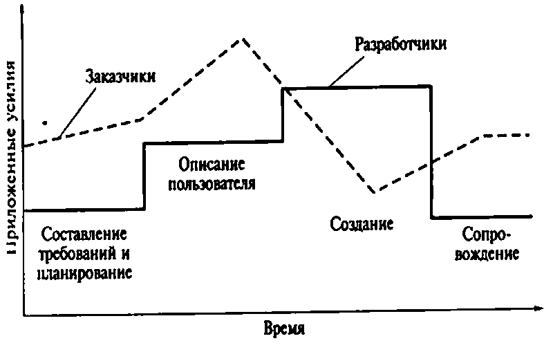

Рис. 2.1. RAD-модель

На стадии анализа и формирования требований: определяют функции, которые должна выполнять система; выделяют наиболее приоритетные функции, требующие проработки в первую очередь; описывают информационные потребности. Формулирование требований к системе осуществляется в основном совместными усилиями пользователей и специалистов-разра- ботчиков. Кроме того, на данной стадии: устанавливаются границы проекта; определяются временные рамки для каждой из последующих стадий; решается сама возможность реализации проекта в заданных размерах финансирования, с имеющимся техническим обеспечением и т.п. В результате завершения стадии должен быть сформулирован перечень функций будущего программного обеспечения и построены предварительные модели ПО.

Стр. 26

На стадии проектирования часть пользователей также принимает участие в проектировании системы под руководством специалистов-раз-работчиков. Для быстрого получения работающих прототипов приложений используются соответствующие инструментальные средства - CASE-средства. Пользователи, непосредственно взаимодействуя с разработчиками, уточняют и дополняют требования в техническом проектировании к системе, которые не были выявлены на предыдушей стадии. На данной стадии более детально рассматриваются процессы системы, создаются частичные прототипы (экранная форма, диалог, отчет), определяется состав необходимой документации.

На стадии реализации непосредственно происходит быстрая разработка приложения. Разработчики производят итеративное построение программного обеспечения на основе полученных на предыдущей стадии моделей, а также требований к надежности, производительности и т.п. Пользователи оценивают получаемые результаты и вносят коррективы, если в процессе разработки ПО перестает удовлетворять определенным ранее требованиям. Тестирование программного обеспечения осуществляется в процессе разработки. Результатом стадии является готовый программный продукт, удовлетворяющий всем согласованным требованиям.

На стадии внедрения производятся обучение пользователей, организационные изменения и параллельно с внедрением нового программного продукта продолжается эксплуатация существующего до полного внедрения нового. Планирование и подготовка к внедрению должны начинаться на стадии проектирования программного продукта.

Следует заметить, что подход RAD не может претендовать на универсальность. Он хорош в первую очередь для относительно небольших проектов, разрабатываемых для конкретного заказчика, и заказчик может принять непосредственное участие в процессе разработки. Если же разрабатывается крупномасштабная программная система, то для такого проекта необходимы высокий уровень планирования, жесткое проектирование, строгое следование заранее разработанным протоколам, что снижает скорость разработки. Подход RAD не применим также для построения сложных расчетных программ, операционных систем или программ управления сложными объектами в реальном масштабе времени, т.е. программ, содержащих большой объем кода. Быстрая разработка не используется для приложений, от которых зависит безопасность людей (например, управление самолетом или атомной электростанцией), так как итеративный подход предполагает, что первые несколько версий наверняка не будут полностью работоспособны, что в данном случае исключается.

Рассмотренный подход можно применять при разработке программных продуктов, которые хорошо поддаются моделированию, когда требования к ПО достаточно хорошо определены.

Стр. 27

При использовании RAD-модели в соответствующем ей проекте проявляются следующие ее достоинства: сокращение продолжительности цикла разработки и всего проекта в целом; сокращение количества разработчиков; вследствие предыдущих факторов - снижение стоимости проекта (также и за счет использования мощных инструментальных средств); сокращение риска несоблюдения графика; сокращение риска, связанного с неудовлетворенностью заказчика полученным программным продуктом, за счет привлечения его к циклу разработки; возможность повторного использования разработанных компонентов; это достоинство проявляется при использовании RAD-мо- дели в составе инкрементной или эволюционной модели. В этом случае наращивание функциональных возможностей осуществляется на базе разработанных ранее компонентов. Основными недостатками RAD-модели при использовании в неподходящем для нее проекте являются: необходимость постоянного участия пользователей в процессе разработки, что не всегда выполнимо и может повлиять на качество конечного продукта; жесткость временных ограничений на разработку прототипа; сложность определения и ограничения затрат и сроков завершения работы над продуктом.

RAD-модель может эффективно применяться в следующих случаях: при разработке программных продуктов, если они поддаются моделированию, являются некритическими, имеют небольшой размер и низкую производительность, относятся к известной разработчикам предметной области, являются информационными системами; требования для программного обеспечения хорошо известны; имеются пригодные к повторному использованию в разрабаты- ваемом ПО компоненты; пользователь может принимать постоянное участие в процессе разработки; в проекте заняты разработчики, обладающие достаточными навыками в использовании инструментальных средств разработки; при разработке ПП, для которых требуется быстрое наращивание функциональных возможностей; при невысокой степени технических рисков; в составе других моделей жизненного цикла.

Стр. 28

# 2.5. Инкрементная модель экстремального программирования

Экстремальное программирование (ХР) - это упрошенная методология организации разработки программ для небольших и средних по размеру команд разработчиков, занимающихся созданием программного продукта в условиях неясных или быстро меняющихся требований. В основе экстремального программирования - очень короткий, постоянно повторяющийся цикл разработки, составляющий од- ну-три недели. К концу каждого цикла вы должны иметь полностью рабочий, функциональный и протестированный релиз приложения. Эти циклы должны быть повторяющимися и бесперебойными на протяжении всего проекта. Предпосылкой для такого режима работы является многократно проверенный факт, что требования редко бывают полными, своевременными и корректными. Как следствие постоянно изменяющихся требований следует другой принцип - позднее принятие решений.

Модель отличается гибкостью, поскольку она ориентирована на высокую степень неопределенности спецификации требований. В соответствии с данной моделью на первом этапе разработки (проектирование архитектуры) усилия разработчиков затрачиваются на тщательное проектирование архитектуры системы и/или программного средства. В дальнейшем уточнение или изменение архитектуры не предусматривается. Результатом данного этапа является модель системы. На втором этапе разработки выполняется планирование очередной версии системы (программного средства). Каждое новое функциональное требование, поступившее к текушему моменту от заказчика, оценивается с точки зрения стоимости и времени его реализации. При этом учитываются результаты оценки неопределенности данных требований и рисков их реализации. С учетом выполненных оценок заказчик выбирает и утверждает новые требования, которые будут реализовываться в очередной версии системы (программного средства).

Следующие этапы разработки выполняются итерационно. Новые требования заказчика реализуются в новом варианте системы (программного средства), выполняются приемочные испытания данного варианта. Если в очередном варианте системы (программного средства) найдены ошибки, то данный вариант возврашается на следую- шую итерацию реализации. Процесс продолжается, пока результаты очередных приемочных испытаний не будут утверждены заказчиком. Утвержденный вариант системы (программного средства) поступает в эксплуатацию в качестве очередной версии.

Стр. 29

Основными целями ХР являются повышение доверия заказчика к программному продукту путем предоставления реальных доказательств успешности развития процесса разработки и резкое сокращение сроков разработки продукта. При этом ХР сосредоточено на минимизации ошибок на ранних стадиях разработки. Это позволяет добиться максимальной скорости выпуска готового продукта и дает возможность говорить о прогнозируемости работы. Практически все приемы ХР направлены на повышение качества программного продукта. Процесс ХР является неформальным, но требует высокого уровня самодисциплины. Если это правило не выполняется, то ХР мгновенно превращается в хаотичный и неконтролируемый процесс. ХР не требует от программистов написания множества отчетов и построения массы моделей. В ХР каждый программист считается квалифицированным работником, который профессионально и с большой ответственностью относится к своим обязанностям. Если в команде этого нет, то внедрять ХР абсолютно бессмысленно - лучше для начала заняться перестройкой команды. Риск разработки снижается только в команде, которой ХР подходит идеально, во всех остальных случаях ХР - это процесс разработки с наиболее высокой степенью риска, поскольку другие методы снижения коммерческих рисков, кроме человеческого фактора, в ХР просто отсутствуют.

Стр. 30

# Глава 3. МОДЕЛИРОВАНИЕ БИЗНЕС-ПРОЦЕССОВ И ПРОЕКТИРОВАНИЕ ПО

# 3.1. Моделирование предметной области

Анализ предметной области предшествует созданию любой информационной системы и является частью ее разработки. На этом этапе определяются потребности пользователей в информации, которые, в свою очередь, предопределяют структуру и содержание базы данных для будущей системы. Предметная область - некоторая совокупность реальных объектов. Каждый из этих объектов обладает определенным набором свойств (атрибутов). Между объектами предметной области могут существовать связи, имеющие различный содержательный смысл. Создавая базу данных для информационной системы, пользователь стремится упорядочить информацию по различным признакам. Это делается для того, чтобы по необходимости извлекать нужную совокупность данных - получать выборку с желаемым сочетанием признаков. Осуществить это возможно только тогда, когда данные структурированы, т.е. отвечают соглашениям о способах представления данных.

Очень важно на этапе проектирования достичь взаимопонимания как между разработчиками системы, так и между экспертами предметной области, заказчиками и т.д., так как каждый имеет свое видение проекта. При этом работа сводится к поэтапному выделению объектов, значимых функций системы, информационных потоков и системы их взаимосвязей. Точки зрения участников разработки по определенным проблемам могут совпадать, при этом формы их представления могут быть различными, что ведет к осложнению совместной работы над одним проектом. Важным инструментом в данном случае является использование единого языка представления проектных решений - языка моделирования. Нужно определить систему обозначений, правил описания процессов, объектов, явлений и их взаимосвязи, позволяющую всем участникам проекта понимать друг друга («говорить на одном языке»).

Стр. 31

Язык моделирования - это набор графических нотаций, которые используются для описания моделей в процессе проектирования. Нотация представляет собой совокупность графических объектов, используемых в модели, и является синтаксисом языка моделирования. Язык моделирования, с одной стороны, должен делать решения проектировщиков понятными пользователю, с другой - предоставлять проектировщикам средства достаточно формализованного и однозначного определения проектных решений, поллежащих реализации в виде программных комплексов, образующих целостную систему. Комплексность подхода и использование единой нотации очень важно не только на этапе моделирования предметной области, но и на последующих этапах разработки программной системы. Изучение предметной области складывается из непосредственного наблюдения протекающих в ней процессов, изучения документов, циркулирующих в системе, а также интервьюирования участников этих процессов.

При разработке модели предметной области определяют некоторые границы, в пределах которых можно развивать логическую модель данных, т.е. моделировать объекты, не выходящие за пределы рассматриваемой предметной области. При этом все второстепенные детали опускаются, чтобы чрезмерно не усложнять процесс анализа и исследования полученной модели. Результатом проведения исследования предметной области должен стать перечень системных требований, спецификаций, информационных потоков и их описание. Очень часто для этого применяются стандартные способы описания предметной области с использованием моделей DFD (диаграмма потоков данных), UML (унифицированный язык моделирования).

Под моделью предметной области понимается некоторая система, имитирующая структуру или функционирование исследуемой предметной области и отвечающая основному требованию - быть адекватной этой области. Модель должна отражать все аспекты функционирования программного обеспечения, и необходима на всех этапах жизненного цикла программного обеспечения. Но особую роль модели предметной области играют на стадии формирования требований к программному продукту при его создании. Модель предметной области - это формализованные знания о предметной области, выраженные при помощи каких-либо средств. В качестве таких средств могут выступать текстовые описания предметной области (должностные инструкции, описание документооборота, примеры первичных документов, выходных отчетов и т.п.). Гораздо более информативными и полезными при разработке программного обеспечения и баз данных являются описания предметной области, выполненные при помощи специализированных графических нотаций. От того, насколько правильно смоделирована предметная область, зависит успех дальнейшей разработки системы.

Стр. 32

Предварительное моделирование предметной области позволяет сократить время и сроки проведения проектировочных работ и получить более эффективный и качественный проект. Без проведения моделирования предметной области велика вероятность допушения большого количества ошибок в решении стратегических вопросов, приводящих к экономическим потерям и высоким затратам на последующее перепроектирование продукта. Модель предметной области должна: обеспечивать формализацию - однозначное описание структуры предметной области; быть понятной для заказчиков и разработчиков и строиться на основе применения графических средств отображения модели; быть реализуемой, т.е. должны быть средства физической реализации модели предметной области; обеспечивать возможности оценки эффективности реализации модели.

Для реализации перечисленных требований необходимо построение системы моделей: объектной модели, отображающей состав взаимодействующих в процессах объектов предметной области; функциональной модели, отображающей взаимосвязь функций (действий) по преобразованию объектов в процессах; технической модели, описывающей расположение и способы взаимодействия комплекса технических средств. Возможно, также потребуются и другие модели, например организационная модель или модель управления, отображающая события и бизнес-правила, которые воздействуют на выполнение процессов. Главный критерий адекватности модели предметной области заключается в функциональной полноте разрабатываемого программного продукта.

С моделированием непосредственно связана проблема выбора языка представления проектных решений. Обычно модели строятся на трех уровнях: внешнем (определение требований); концептуальном (спецификации требований); внутреннем (реализация требований). Так, на внешнем уровне определяется состав основных компонентов программного обеспечения: объектов, функций, событий, организационных единиц, технических средств. На концептуальном - определяется характер взаимодействия компонентов системы. На внутреннем уровне с помощью модели дается ответ на вопрос: «с помощью каких программно-технических средств реализуются требования к системе»?

При работе с большими и сложными программами проблема сложности является главной проблемой. Ни один разработчик не в состоянии выйти за пределы человеческих возможностей и понять всю систему в целом. Единственный эффективный подход к решению этой проблемы заключается в построении сложной системы из небольшого количества крупных частей, каждая из которых, в свою очередь, строится из частей меньшего размера. Так до тех пор, пока самые небольшие части легких и доступных для восприятия и понимания. Это означает, что сложную программную систему нужно разделять (декомпозировать) на небольшие подсистемы, каждую из которых можно рассматривать независимо от других.

Стр. 33

# 3.2. Методы проведения обследования предметной области

Перед началом работ по проведению обследования предметной области необходимо выбрать метод проведения обследования. Все методы можно объединить в группы по различным признакам. По цели обследования выделяют:метод организации локального проведения обследования, используемый для разработки проекта отдельной задачи или для комплекса задач; метод системного обследования объекта, применяемый для изучения всего объекта с целью разработки для него проекта программного обеспечения в целом. По числу исполнителей, проводящих обследование: индивидуальное обследование, осуществляемое одним проектировщиком;бригадное обследование, с выделением ряда бригад-исполнителей, изучающих все аспекты предметной области, и одной координирующей бригады. По степени охвата предметной области: метод сплошного обследования например, охватывающий все подразделения производственной или экономической системы; выборочное обследование, применяемое при наличии типовых по структуре объектов.

Существуют также методы последовательного и параллельного проведения работ: метод последовательного проведения работ, при котором проектировщики сначала собирают данные о предметной области, а затем их изучают (часто применяют при отсутствии опыта в выполнении такого рода работ); метод параллельного выполнения работ, когда одновременно со сбором происходит изучение полученных материалов обследования, что значительно сокращает время на проведение предпроектной стадии и повышает качество получаемых результатов.

Стр. 34

Выполнение работ по обследованию предметной области и сбору материалов можно проводить на основе предварительного выбора методов, совокупность которых можно разделить на следуюшие группы: методы сбора информации, выполняемого проектировщиками, - включают методы проведения бесед и опросов, анализа материалов обследования, личных наблюдений (например, фотографии рабочего дня и хронометража рабочего времени специалиста при выполнении им той или иной работы); методы сбора информации специалистами предметной области - проведение документальной инвентаризации рабочего места либо использование метода фотографии рабочего дня, позволяющего выявить состав операций и получаемые при этом документы, и т.д.; метод бесед и консультаций с руководителями предприятий и подразделений, групп будущих пользователей либо со специалистами по вопросам, относящимся к определению проблем; метод опроса исполнителей на рабочих местах. Заранее составляется список сотрудников, с которыми необходимо провести беседу, разрабатывается перечень вопросов о роли и назначении работ в деятельности объекта, порядке их выполнения; метод анализа операций, который заключается в расчленении рассматриваемого процесса, работы на составные части, задачи, расчеты, операции, элементы. После этого анализируется каждая часть в отдельности, выявляются повторяемость отдельных операций, многократное обращение к одной и той же операции, их степень зависимости друг от друга и т.д.

# 3.3. Составление спецификаций по требованиям заказчика

В результате анализа требований к будущему программному продукту получают его спецификации: выполняют декомпозицию и содержательную постановку решаемых задач, уточняют их взаимодействие и определяют эксплуатационные ограничения. Спецификациями называют точное формализованное описание функций и ограничений разрабатываемого программного продукта. Функциональная спецификация в разработке программного обеспечения - это документ, описывающий требуемые характеристики системы (функциональность). Эксплуатационная спецификация - это описание правил использования программного обеспечения. Эксплуатационные спецификации определяют требования к техническим средствам, надежности, безопасности и т.д. Совокупность спецификаций представляет собой общую логическую модель проектируемого программного обеспечения.

В целом в процессе определения спецификаций строят обшую модель предметной области как некоторой части реального мира, с которой будет тем или иным способом взаимодействовать разраба- тываемое программное обеспечение, и конкретизируютего основные функции. Функциональные спецификации должны быть полными и точными. Требование полноты означает, что спецификации должны содержать всю существенную информацию, чтобы ничего важного не было упущено, и не должны содержать несущественной информации, например деталей реализации, чтобы не препятствовать разработчику в выборе наиболее эффективных решений. Требование точности означает, что спецификации должны однозначно восприниматься как заказчиком, так и разработчиком.

Стр. 35

Функциональная спецификация состоит из трех частей. Во первых. Описание внешней информационной среды, с которой будет взаимодействовать разрабатываемое программное обеспечение. Должны быть определены все способы взаимодействия с внешней средой, все информационные объекты, к которым будет применяться разрабатываемое ПО, а также существенные связи между этими информационными объектами. Во вторых. Определение функций программного обеспечения, определенных на множестве состояний этой информационной среды. Вводятся обозначения всех определяемых функций, специфицируются их входные данные и результаты выполнения с указанием типов данных и заданий всех ограничений, которым должны удовлетворять эти данные и результаты. Определяется содержание каждой из этих функций. В третьих. Описание исключительных ситуаций, если таковые могут возникнуть при выполнении программ, и реакций на эти ситуации, которые должны обеспечить соответствующие программы. Должны быть перечислены все существенные случаи, когда программное обеспечение не сможет нормально выполнить ту или иную свою функцию. Для каждого такого случая должна быть определена реакция программы.

Стр. 36

Все функциональные спецификации разрабатываемого программного обеспечения описывают перечень функций и состав обрабатываемых данных. Они различаются только системой приоритетов (акцентов), которая используется разработчиком и пронессе анализа требований и определения спенификаний. Утверждение требований исполнителем и заказчиком опрелеляет момент достижения соглашения межлу ними по всем пунктам спен- ификаций требований, Заказчик может потребовать предоставить ему прототип или иной пример, иллюстрируюший проверку иеко- торых требований к программному обеспечению, может опрелелить множество проверочных примеров или многократно изменить параметры отдельных требований к ПП. В этом случае такие пожелания заказчика необходимо оформлять в приложении к спепификациям требований. При составлении спецификаций не слелует употреблять слова и словосочетания, допускаюшие неоднозначное толкование. Точные спецификации разрабатываемого программного обеспечения можно определить, только разработав некоторую формальную модель этого программного обеспечения.

# 3.4. Технология проектирования программного обеспечения

Задача этапа проектирования - определение подробных спецификаций разрабатываемого программного обеспечения. Процесс проектирование программного обеспечения обычно включает: проектирование общей структуры - определение основных частей (компонентов) и их взаимосвязей по управлению и данным; декомпозицию компонентов и построение структурных иерархий в соответствии с рекомендациями блочно-иерархического подхода; проектирование компонентов. Результатом проектирования является детальная модель разрабатываемого программного обеспечения вместе со спецификациями его компонентов всех уровней. Тип модели зависит от выбранного или заданного подхода (структурный, объектно-ориентированный) и конкретной технологии проектирования. Однако в любом случае процесс проектирования охватывает как проектирование программ (подпрограмм) и определение взаимосвязей между ними, так и проектирование данных, с которыми взаимодействуют эти программы или подпрограммы.

Принято различать также два аспекта проектирования:логическое проектирование, включающее те проектные операции, которые непосредственно не зависят от имеющихся технических и программных средств, составляющих среду функционирования будушего программного продукта; физическое просктирование, которое заключается в привязке к конкретным техническим и программным средствам среды функционирования. Методологии, технологии и инструментальные средства проектирования составляют основу проекта любого программного продукта. Методология реализуется через конкретные технологии и поддерживающие их стандарты, методики и инструментальные средства, которые обеспечивают выполнение процессов в жизненном цикле.

Стр. 37

Технология проектирования определяется как совокупность технологических операций проектирования в их последовательности и взаимосвязи, приводящая к разработке проекта. Технологию проектирования можно представить как совокупность трех составляющих: пошаговой процедуры, определяюшей последовательность технологических операций проектирования; критериев и правил, используемых для оценки результатов выполнения технологических операций; нотаций (графических и текстовых средств), используемых для описания проектируемой программной системы. Реальное применение любой технологии проектирования, разработки и сопровождения программного продукта в конкретной организации и конкретном проекте невозможно без выработки ряда стандартов (правил, соглашений), которые должны соблюдаться разработчиками. К таким стандартам относятся стандарт проектирования, стандарт оформления проектной документации, стандарт пользовательского интерфейса.

Основу технологии проектирования программного обеспечения составляет методология, которая определяет сущность, основные отличительные технологические особенности. Методология реализуется через конкретные технологии и поддерживающие их стандарты, методики и инструментальные средства, которые обеспечивают выполнение процессов жизненного цикла. Методология проектирования предполагает наличие некоторой концепции, принципов проектирования, реализуемых набором методов проектирования, которые, в свою очередь, должны поддерживаться некоторыми средствами проектирования.

Стр. 38

По степени использования типовых проектных решений различают методы: оригинального (инливидуального) проектирования, когда проектные решения разрабатываются «с нуля» в соответствии с требованиями к программному обеспечению. Оригинальное проектирование программного обеспечения характеризуется тем, что все виды проектных работ ориентированы на создание индивидуальных для каждого объекта проектов, которые в максимальной степени отражают все его особенности. Типового проектирования, предполагающего конфигуранию ПО из готовых типовых проектных решений (программных модулей). Типовое проектирование выполняется на основе опыта, полученного при разработке индивидуальных проектов. Типовые проекты как обобщение опыта для некоторых групп организационно-эко- номических систем или видов работ в каждом конкретном случае связаны со множеством специфических особенностей и различаются по степени охвата функций управления, выполняемым работам и разрабатываемой проектной документации.

# 3.5. Структурно-функциональный подход к разработке программного обеспечения

Сушность структурного подхода к разработке программного обеспечения заключается в его декомпозиции (разбиении) на автомати- зируемые функции: система разбивается на функциональные подсистемы, которые, в свою очередь, делятся на подфункции, подраз- деляемые на задачи, и т. д. Процесс разбиения продолжается вплоть до конкретных процедур. При этом автоматизируемая система сохраняет целостное представление, в котором все составляющие компоненты взаимоувязаны. Следует отметить, что при обратной рара- ботке системы («снизу-вверх») от отдельных задач ко всей системе целостность теряется, возникают проблемы при информационной стыковке отдельных компонентов. Все наиболее распространенные методологии структурного подхода базируются на таких принципах, как: принцип «разделяй и властвуй» - принцип решения сложных проблем путем их разбиения на множество меньших независимых задач, легких для понимания и решения; принцип иерархического упорядочивания - принцип организации составных частей проблемы в иерархические древовидные структуры с добавлением новых деталей на каждом уровне. В структурном анализе используются группы средств, иллюстрирующих функции, выполняемые системой, и отношения между данными. Каждой группе средств соответствуют определенные виды моделей (диаграмм), наиболее распространенными среди которых являются следующие: метод SADT (Structured Analisis and Design Technique) - метод структурного анализа и проектирования, модели и соответствую- шие диаграммы; метод DFD (Data Flow Diagrams) - диаграммы потоков данных; метод ERD (Entity-Relationship Diagrams) - диаграммы «сущ- ность-связь» (модель данных). Перечисленные модели в совокупности дают полное описание программного обеспечения независимо от того, является оно сушествующим или вновь разрабатываемым. Состав диаграмм в каждом конкретном случае зависит от необходимой полноты описания программного обеспечения.

Стр. 39

# 3.6. Методология функционального моделирования SADT

Функциональные диаграммы отражают взаимные связи функций разрабатываемого программного обеспечения. Они создаются на ранних стадиях проектирования систем, для того чтобы помочь про- ектировщику выявить основные функции и составные части проектируемой программной системы и, по возможности, обнаружить и устранить существенные ошибки. Для создания функциональных диаграмм предлагается использовать методологию SADT, предложенную Д. Россом. На основе методологии SADT была построена известная методология описания сложных систем IDEFO (Icam DEFinition), которая является основной частью программы ICAM (интегрированная компьютеризация производства), проводимой по инициативе BВC США. Результатом применения методологии SADT является модель, которая состоит из диаграмм, фрагментов текстов и глоссария, имеющих ссылки друг на друга.

Методология SADT может использоваться для моделирования предметной области программного обеспечения и определения требований и функций, а также для разработки программного обеспечения, которое удовлетворяет этим требованиям и реализует эти функции. SADT может быть использована в анализе существующего программного продукта для анализа функций, выполняемых ПП, и для указания механизмов, посредством которых они осуществляются. Диаграммы - главные компоненты модели. Функции системы и интерфейсы представлены на диаграммах как блоки и дуги. Место соединения дуги с блоком определяет тип интерфейса. Управляющая информация входит в блок сверху, в то время как информация, которая подвергается обработке, показана с левой стороны блока, а результаты выхода показаны с правой стороны. Механизм (человек или автоматизированная система), который осуществляет операцию, представляется дугой, входящей в блок снизу (рис. 3.1).

Стр. 40

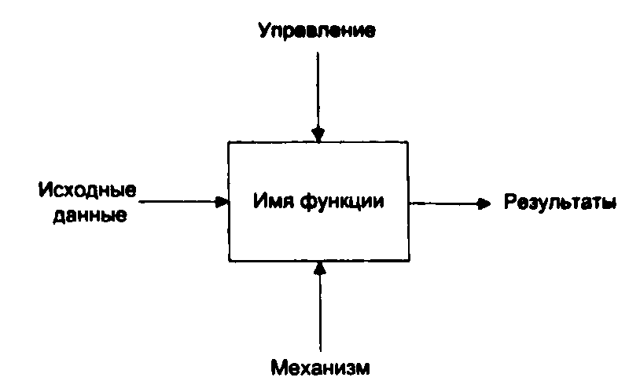

Рис. 3.1. Функциональный блок и интерфейсные дуги

Модель SADT представляет собой серию диаграмм с сопроводительной документацией, разбивающих сложный объект на составные части, которые представлены в виде блоков. Одной из наиболее важных особенностей методологии SADT является постепенное введение все больших уровней детализации по мере создания диаграмм, отображающих модель. Детали каждого из основных блоков показаны в виде блоков на других диаграммах. Каждая детальная диаграмма является декомпозицией блока из более общей диаграммы. На каждом шаге декомпозиции более общая диаграмма называется родительской для более детальной диаграммы.

Построение SADT-модели начинается с представления всей системы в виде простейшей компоненты - одного блока и дуг, изображающих интерфейсы с функциями вне системы. Поскольку единственный блок представляет всю систему как единое целое, имя, указанное в блоке, является общим. Это верно и для интерфейсных дуг - они также представляют полный набор внешних интерфейсов системы в целом. Затем блок, который представляет систему в качестве единого модуля, детализируется на другой диаграмме с помощью нескольких блоков, соединенных интерфейсными дугами. Эти блоки представляют основные подфункции исходной функции. Данная декомпозиция выявляет полный набор подфункций, каждая из которых представлена как блок, границы которого определены интерфейсными дугами. Каждая из этих подфункций может быть деком- позирована подобным образом для более детального представления. Во всех случаях каждая подфункция может содержать только те элементы, которые входят в исходную функцию. Кроме того, модель не может опустить какие-либо элементы, т.е., как уже отмечалось, родительский блок и его интерфейсы обеспечивают контекст. К нему нельзя ничего добавить и из него не может быть ничего удалено.

Стр. 41

Дуги, входящие в блок и выходящие из него на диаграмме верхнего уровня, являются точно теми же самыми, что и дуги, входящие в диаграмму нижнего уровня и выходящие из нее, потому что блок и диаграмма представляют одну и ту же часть системы. Все диаграммы связывают друг с другом иерархической нумерацией блоков: первый уровень - А0, следующий - Al, A2 и т.п., следующий - Al1, Al2, А13 и т.д., где первые цифры - номер родительского блока, а последняя - номер конкретного субблока родительского блока (рис. 3.2). Каждая диаграмма иллюстрирует «внутреннее строение» блока на родительской диаграмме. Детализацию завершают при получении функций, назначение которых хорошо понятно как заказчику, так и разработчику. Эти функции описывают, используя естественный язык или псевдокоды. В процессе построения иерархии диаграмм фиксируют всю уточняющую информацию и строят словарь данных, в котором определяют структуры и элементы даиных, показанных на диаграммах. Таким образом, в результате получают спецификацию, которая состоит из иерархии функциональных диаграмм, описаний функций нижнего уровня и словаря, имеющих ссылки друг на друга.

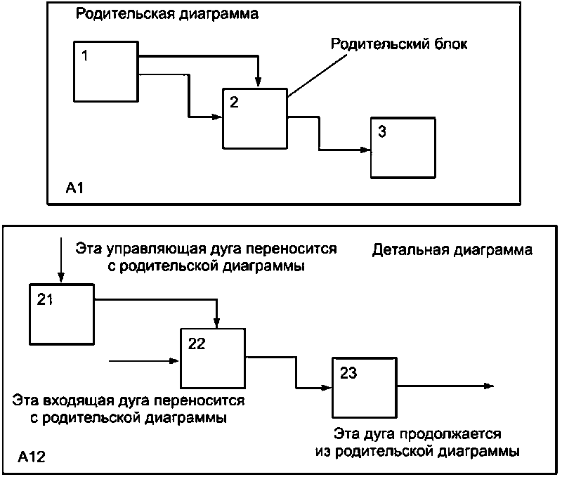

Рис. 3.2. Соответствие интерфейсных дуг родительской и детальной диаграмм

На SADT-диаграммах не указаны явно ни последовательность, ни время. Обратные связи, итерации, продолжающиеся процессы и перекрывающиеся (по времени) функции могут быть изображены также с помощью дуг. Обратные связи могут выступать в виде комментариев, замечаний, исправлений и т.д.

Стр. 42

Приведем пример построения функциональной диаграммы для автоматизации процесса приема и зачисления абитуриентов. Диаграмма, показанная на рис. 3.3, является диаграммой верхнего уровня. На ней хорошо видно, что является исходными данными для системы, и получение каких результатов мы ожидаем. На функциональной диаграмме нулевого уровня (рис. 3.4) родительский блок А0 разбивается на функциональные блоки А1, А2, А3, А4. В свою очередь, блок Al может быть представлен на функциональной диаграмме 1-го уровня как четыре дочерних блока A11, A12, A13, A14 (рис. 3.5). Метод SADT может использоваться для моделирования самых разнообразных систем и определения требований и функций. В существующих системах данный метод может применяться для анализа функций, выполняемых системой.

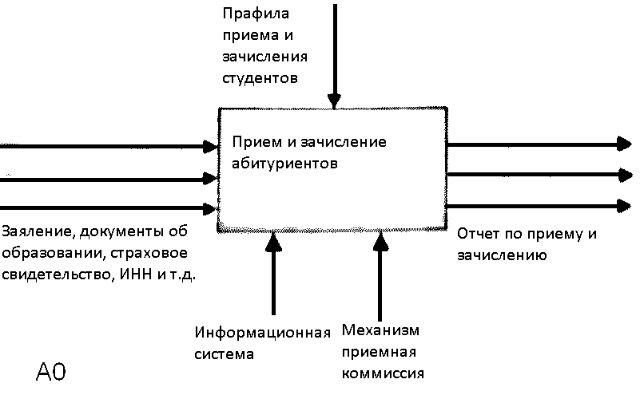

Рис. 3.3. Функциональная диаграмма начального уровня

Стр. 43

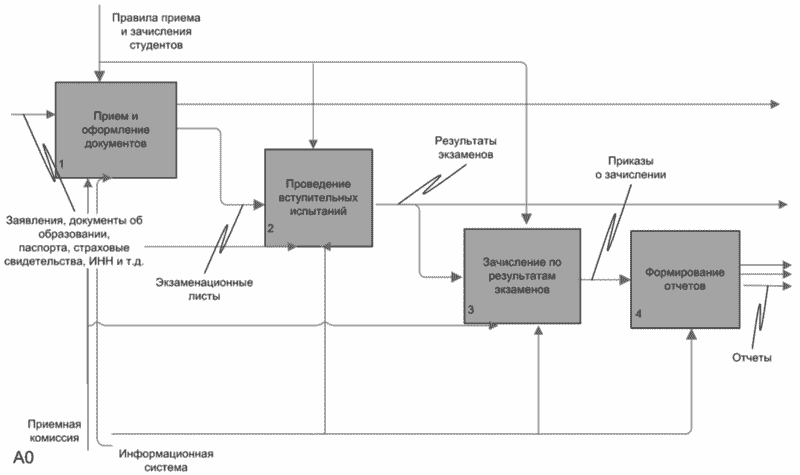

Стр. 44

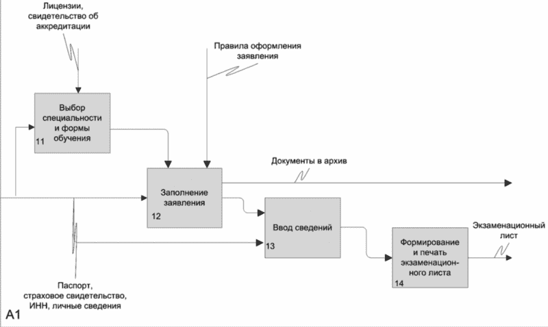

Рис. 3.5. Функциональная диаграмма I-го уровня - «Прием и оформление документов»

Стр. 45

# 3.7. Диаграммы потоков данных DFD

Диаграмма потоков данных (DFD) является средством моделирования функциональных требований к системе - проектируемой или реально существующей. DFD состоит из узлов обработки данных, средств хранения данных и внешних по отношению к используемой диаграмме источников или потребителей данных. В основе модели лежат понятия внешней сущности, процесса, хранилища (накопителя) данных, а также потока данных. Источники информации (внешние сущности) порождают информационные потоки (потоки данных), переносящие информацию к подсистемам или процессам. Те, в свою очередь, преобразуют информацию и порождают новые потоки, которые переносят информацию к другим процессам или подсистемам, накопителям данных или внешним сущностям - потребителям информации. Для изображения диаграмм потоков данных традиционно используют два вида нотаций: нотации Йордана и Гейна-Сарсона, которые представлены в табл. 3.1.

# Нотации, используемые в DFD

Нотация Йордана

- Внешняя сущность

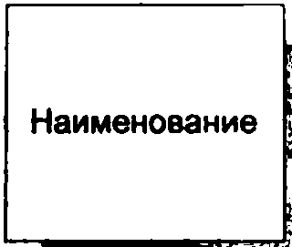

- Система, подсистема или процесс

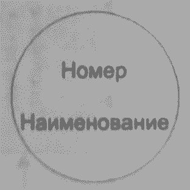

- Накопители данных

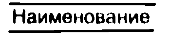

- Поток

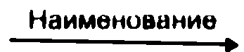

# Нотация Гейна-Сарсона

- Внешняя сущьность

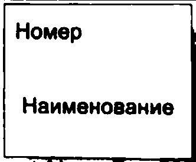

- Система, подсистема или процесс

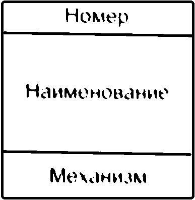

Накопители данных

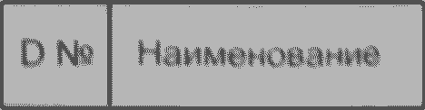

Поток

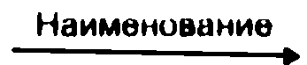

Стр. 46

Внешняя сущность - это материальный предмет или физическое лицо, представляющие собой источник или приемник информации, например заказчики, персонал, поставщики, клиенты, склад. Определение некоторого объекта или системы в качестве внешней сущности указывает на то, что она находится за пределами границ анализируемой информационной системы. В процессе анализа некоторые внешние сущности могут быть перенесены внутрь, если это необходимо, или, наоборот, часть процессов информационной системы может быть вынесена за пределы диаграммы и представлена как внешняя сущность. При построении модели сложной информационной системы она может быть представлена в самом общем виде на так называемой контекстной диаграмме в виде одной системы как единого целого либо декомпозирована на ряд подсистем. Номер подсистемы служит для ее идентификации. В поле имени вводится наименование подсистемы в виде предложения с подлежащим и соответствующими определениями и дополнениями.

Процесс представляет собой преобразование входных потоков данных в выходные в соответствии с определенным алгоритмом. Физически процесс может быть реализован различными способами: это может быть подразделение организации (отдел), выполняющее обработку входных документов и выпуск отчетов, программа, аппаратно реализованное логическое устройство и т.д. Номер процесса служит для его идентификации. В поле имени вводится наименование процесса, при этом использование таких глаголов, как обработать, модернизировать или отредактировать означает, как правило, недостаточно глубокое понимание данного процесса и требует дальнейшего анализа. Наименование процесса должно четко определять конкретные действия. Информация в поле физической реализации показывает, какое подразделение организации, программа или аппаратное устройство выполняет данный процесс.

Накопитель данных - это абстрактное устройство для хранения информации, которую можно в любой момент поместить в накопитель и через некоторое время извлечь, причем способы помещения и извлечения могут быть любыми. Накопитель данных может быть реализован физически в виде ящика в картотеке, таблицы в оперативной памяти, файла на магнитном носителе и т.д. В нотации Гейна-Сарсона накопитель данных идентифицируется буквой D и произвольным числом. Имя накопителя выбирается из соображения наибольшей информативности. Накопитель данных в общем случае является прообразом базы данных, и описание хранящихся в нем данных должно быть увязано с информационной моделью. Поток данных определяет информацию, передаваемую через некоторое соединение от источника к приемнику. Реальный поток данных может быть информацией, передаваемой по кабелю междудвумя устройствами, пересылаемыми по почте письмами, магнитными лентами или дискетами, переносимыми с одного компьютера на другой, и т.д. Каждый поток данных имеет имя, отражающее его содержание.

Стр. 47

Построение иерархии диаграмм потоков данных начинают с контекстной диаграммы, которая определяет наиболее общий вид системы. На такой диаграмме описывают интерфейс системы с внешним миром, т.е. показывают, как разрабатываемая система булет взаимодействовать с потребителями и источниками информации. Обычно начальная контекстная диаграмма имеет формузвезды. Если система содержит большое количество внешних сущностей (более 10), имеет распределенную природу или включает уже существующие подсистемы, то строят иерархии контекстных диаграмм. В процессе детализации соблюдают правило балансировки - при детализации подсистемы могут использоваться компоненты только тех подсистем, с которыми у анализируемой подсистемы существует информационная связь (т.е. с которыми она связана потоками данных). На не детализируемые процессы составляют спецификации, которые должны содержать описание функций данного процесса. Такое описание может выполняться на естественном языке.

Приведем пример построения диаграммы потоков данных для разработки программного обеспечения автоматизированной информационной системы «Склад оптовой торговли», предназначенной для получения данных о движении и наличии товаров, приобретенных для оптовой продажи. Построение иерархии диаграмм потоков данных начинается с контекстной диаграммы, т.е. определяем, как разрабатываемая система будет взаимодействовать с приемниками и источниками информации (рис. 3.6). Первичные документы по приходу товаров фиксируются в журнале поступления товаров. Оформление и учет реализации товаров зависят от способа расчета за приобретаемые товары между покупателем и продавцом. Менеджер склада ведет журнал учета закупок и отпуска товаров. Данные первичных документов сохраняются в соответствующих накопителях.

Внешними сущностями для разрабатываемой системы являются поставщики, покупатели, менеджер склада, отдел учета и контроля, отдел приема и оформления заказов. Сведения о них сохраняются в соответствующих таблицах (справочниках). Поставщик передает товар на склад. Документы на поставку товара (накладные, счета-фактуры) вводятся в базу данных. Покупатель подает заказ на приобретение товаров. В отделе приема и оформления заказов проверяется каждая строка поступившего заказа. При отсутствии на складе какой-либо позиции оформляется заявка поставщику, т.е. инициируется поставка необходимого товара. На основании заказа заполняются документы на реализацию товара, которые сохраняются в базе данных, распечатываются и выдаются покупателю. В конце каждого дня все первичные документы передаются бухгалтеру. На основании сведений о приходе и реализации товара менеджеры склада и работники отдела учета формируют отчеты по оборотам и остаткам товара на складе. Диаграмма потоков данных АИС «Склад оптовой торговли» представлена на рис. 3.7.

Стр. 48

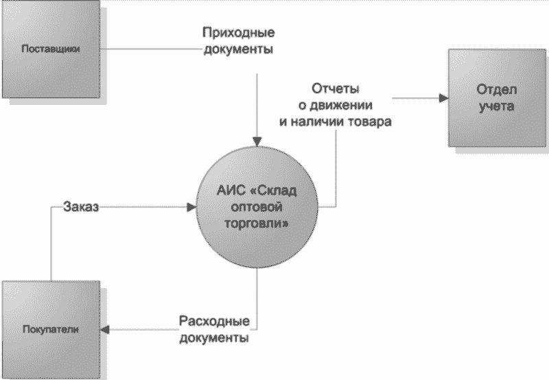

Рис. 3.6. Начальная контекстная диаграмма (диаграмма нулевого уровня) в нотации Йордана для АИС «Склад оптовой торговли»

# 3.8. Функциональная схема

Процесс проектирования программного обеспечения включает в себя определение структурных компонентов программной системы и связей между ними. Результат уточнения структуры может быть представлен в виде различных схем, дающих наиболее полное представление о проектируемом программном обеспечении. Схемы могут использоваться на различных уровнях детализации, причем число уровней зависит от размеров и сложности задачи обработки данных. Уровень детализации должен быть таким, чтобы различные части и взаимосвязь между ними были понятны в целом. Функциональная схема - это схема взаимодействия компонентов программного обеспечения с описанием информационных потоков, состава данных в потоках и указанием используемых файлов и устройств. Для изображения функциональных схем используют специальные обозначения, установленные стандартом (ГОСТ 19. 701-90 ). Все компоненты функциональных схем должны быть описаны (табл. 3.2).

Стр. 49

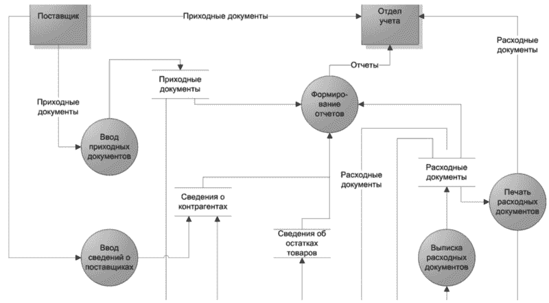

Стр. 50

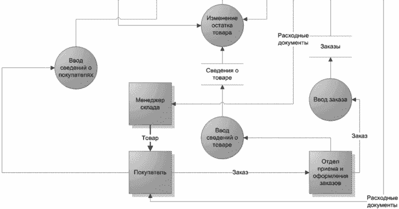

Рис. 3.7. Диаграмма потоков данных АИС «Склад оптовой торговли

Стр. 51

Графические обозначения основных блоков алгоритмов

- Терминатор

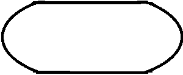

Символ отображает выход во внешнюю среду и вход из внешней среды (начало или коней схемы программы, внешнее использование и источник или пункт назначения данных)

- Данные

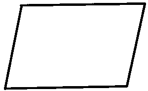

Отображает данные, носитель данных не определен

- Запоминающее устройство с прямым доступом

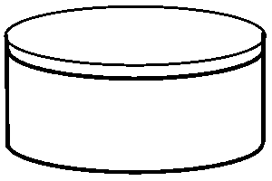

Отображает данные, хранящиеся в запоминающем устройстве с прямым доступом (магнитный диск, магнитный барабан, гибкий магнитный диск)

- Документы

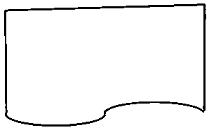

Отображает данные, представленные на носителе в удобочитаемой форме (машинограмма, документ для оптического или магнитного считывания, микрофильм, рулон ленты с итоговыми данными, бланки ввода данных)

- Ручной ввод

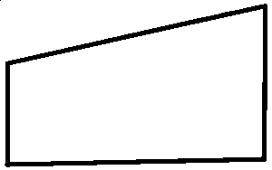

Отображает данные, вводимые вручную во время обработки с устройств любого типа (клавиатура, переключатели, кнопки, световое перо, полоски со штриховым кодом)

- Дисплей

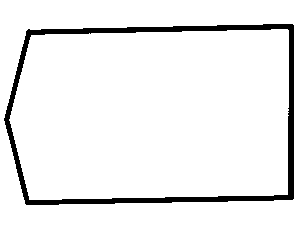

Отображает данные, представленные в человекочитаемой форме на носителе в виде отображающего устройства (экран для визуального наблюдения, индикаторы ввода информации)

- Процесс

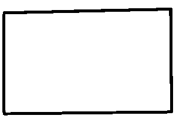

Отображает функцию обработки данных любого вида (выполнение определенной операции или группы операций, приводящее к изменению значения, формы или размещения информации или к определению, по которому из нескольких направлений потока следует двигаться)

- Предопределенный процесс

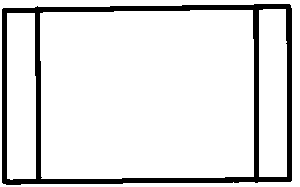

Символ отображает предопределенный процесс, состоящий из одной или нескольких операций или шагов программы, которые опреде лены вдругом месте (в подпрограмме, модуле). На рис. 3.8 приведена функциональная схема программной системы, реализующей операцию продажи товара автоматизированной информационной системы "Склад оптовой торговли".

Стр. 52

[figure not shown]

Рис. 3.8. Пример функциональной схемы программного обеспечения подсистемы реализации АИС «Склад оптовой торговли»

Стр. 53

При структурном подходе особенно тщательно необходимо прорабатывать спецификации межпрограммных интерфейсов, так как от качества их описания зависит количество самых дорогостоящих ошибок. К самым дорогим относятся ошибки, обнаруживаемые при комплексном тестировании, так как для их устранения могут потребоваться серьезные изменения уже отлаженных текстов.

Стр. 54

# Глава 4. МЕТОДЫ РАЗРАБОТКИ ПО На языкАХ ВЫсОКОго уровня

## 4.1 Сущность объектно-ориентированного метода в программировании

Объектный подход к программированию сложился с середины 80-х до конца 90-х годов прошлого века. Объектно-ориентированное программирование (ООП) определяется как технология создания сложного программного обеспечения, основанная на представлении программы в виде совокупности объектов, каждый из которых является экземпляром определенного типа (класса), а классы образуют иерархию с наследованием свойств. Взаимодействие программных объектов осуществляется путем передачи сообщений. Основное достоинство объектно-ориентированного программирования по сравнению с модульным программированием - более естественная декомпозиция программного обеспечения, которая существенно облегчает его разработку. Кроме того, объектный подход предлагает новые способы организации программ, основанные на механизмах наследования, полиморфизма, композиции. Это позволяет существенно увеличить показатель повторного использования кодов и создавать библиотеки классов для различных применений.

Развитие объектного подхода в технологии программирования привело к созданию сред визуального программирования. Появились языки визуального объектно-ориентированного программирования, такие как Delphi, C++ Builder, Visual C++, C# и т. д. Однако технология ООП имеет и недостатки, Главный из них - зависимость модулей программного обеспечения от адресов экспортируемых полей и методов, структур и форматов данных. Эта зависимость объективна, так как модули должны взаимодействовать между собой, обращаясь к ресурсам друг друга. Любые программные системы предназначены для моделирования реальных систем, поэтому очень важно, в каких терминах мы пытаемся описать эти реальные системы. Описание в виде последовательности действий (процедурный подход к программированию) оказалось довольно сложным. Объектно-ориентированный подход предлагает описывать системы в виде взаимодействия объектов. Основным понятием объектно-ориентированного программирования является объект. Вообще, такой подход представляется достаточно естественным, поскольку в реальном мире мы имеем дело именно с объектами (предметами, устройствами, людьми), взаимодействующими друг с другом. И взаимодействие пользователей с компьютерной программой - это тоже взаимодействие двух объектов - программы и человека, которые обмениваются друг с другом сообщениями.

Стр. 55

Объект в объектно-ориентированном программировании - это модель или абстракция реальной сущности в программной системе. Объектно-ориентированная программа - совокупность объектов и способов их взаимодействия. Задача, решаемая с использованием методики ООП, описывается в терминах объектов и операций над ними. Любая программа, написанная на языке ООП, отражает в своих данных состояние физических предметов либо абстрактных понятий - объектов программирования, для работы с которыми она предназначена. Каждый объект в объектно-ориентированном программировании характеризуется своим состоянием. Состояние объекта описывается текущим значением его атрибутов (данных). Атрибутами объекта в ООП могут быть как простейшие значения (число, логическое значение и т.д.), так и сложные величины или другие объекты. Исходя из этого, можно определить объект как некую совокупность данных и способов работы с ними. Иначе говоря, все данные об объекте программирования и его связях с другими объектами можно объединить в одну структурированную переменную, называемую объектом. Данные (характеристики объекта) можно рассматривать как поля записи. Пользователи и объекты программы должны иметь возможность читать эти данные объекта, каким-то образом обрабатывать и записывать в объект новые значения.

С объектом связывается набор действий, иначе называемых методами. С точки зрения языка программирования набор действий или методов - это функции, получающие в качестве обязательного параметра указатель на объект и выполняющие определенные действия с данными объекта программирования. Технология ООП позволяет работать с объектом только через его методы и никак иначе, т.е., внутренняя структура объекта скрыта от внешнего пользователя. Прямой доступ к данным запрещен пользователю, и делается это по следующим причинам. Для надежного функционирования объекта надо поддерживать целостность и непротиворечивость его данных. Если не позаботиться об этом, то внешний объект или пользователь могут разрушить или занести неверные данные, и объект будет функционировать с ошибками. Необходимо изолировать внешние объекты от особенностей внутренней реализации данных. Для внешних потребителей данных должен быть доступен только пользовательский интерфейс - описание того, какие имеются данные и функции и как их можно использовать, а внутренняя реализация - это дело разработчика объекта. В таком случае разработчик всегда может модернизировать объект, изменить структуру хранения и форму представления данных, и если не затронуты внешние интерфейсы, то пользователь этого даже не заметит. Следовательно, в программе и в действиях пользователя не придется ничего менять.

Стр. 56

Чтобы обеспечить сокрытие данных, в объекте определяются процедуры и функции, реализующие все необходимые операции с данными (чтение, преобразование, запись). Через эти процедуры и функции (методы) происходит общение с данными объекта. Компилятор вставляет в нужных местах программы вызовы этих методов. Таким образом, взаимодействие объектов (обмен сообщениями между объектами) на самом деле представляет собой вызов того или иного метода объекта. Совокупность данных и методов их чтения и записи называют свойством. Свойства можно устанавливать в процессе проектирования, изменять во время выполнения программы. Помимо методов, работающих с отдельными данными, в объекте имеются методы, работающие со всей их совокупностью, меняющие их структуру. Таким образом, объект можно определить, как совокупность свойств и методов. Средой взаимодействия объектов являются сообщения, генерируемые в результате различных событий. События наступают вследствие действий пользователя (нажатие кнопок мыши или клавиатуры, перемещение курсора мыши). Также события могут наступать в результате работы самих объектов. В каждом объекте определено множество событий, на которые он может реагировать. В конкретных экземплярах объекта могут быть установлены обработчики этих событий, которые и определяют реакцию данного экземпляра объекта.

Стр. 57

Исходя из вышеизложенного, можно дать следующее определение объекта. Объект - это совокупность свойств и методов, а также событий, на которые он может реагировать. Состояние объекта характеризуется перечнем всех возможных статических свойств данного объекта и текущими значениями (динамическими) каждого из этих свойств. Поведение характеризует воздействие объекта на другие объекты и наоборот относительно изменения состояния этих объектов. Другими словами, поведение объекта полностью определяется его действиями. Важнейшей характеристикой объекта в объектно-ориентированном программировании является описание того, как он может взаимодействовать с окружающим миром. Это описание называется интерфейсом объекта. Условно схему органиации объекта можно представить следующим образом (рис. 4.1). Внешнее управление объектом осуществляется через обработчики событий. Эти обработчики обращаются к свойствам и методам объекта. Начальные значения данных объекта могут задаваться также в процессе проектирования установкой различных свойств. В результате выполнения методов объекта могут генерироваться новые события, воспринимаемые другими объектами программы или пользователем.

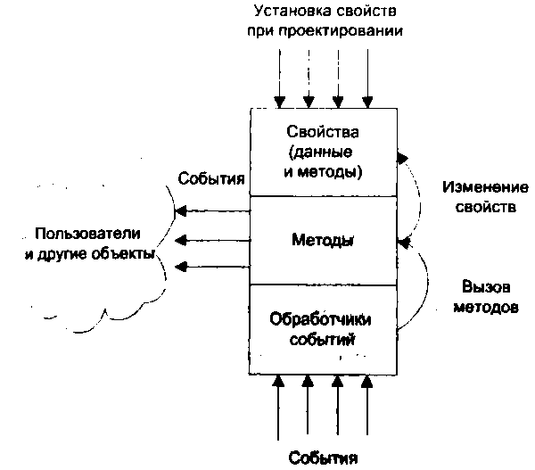

Рис. 4.1. Схема организации объекта

Индивидуальность - это свойства объекта, отличающие его от всех других объектов, Иногда нужно идентифицировать объекты в ООП. Если имеются два объекта, то нужно как-то определить, что эти объекты разные. Обычно для идентификации применяются специальные атрибуты объектов - идентификаторы. В любой системе объекты создаются, функционируют и уничтожаются. В программировании существуют два способа уничтожения объектов: объекты должны уничтожаться явно, с помощью специальных вызовов; объекты уничтожаются тогда, когда они никому не нужны (в системе отсутствуют все ссылки на данный объект). Такое уничтожение иногда называется уничтожением по достижимости.

Стр. 58

Но в то же время могут существовать объекты, для которых необходимо восстанавливать их предыдущее состояние при новом запуске программы. Для работы с такими объектами применяется метол сериализации, когда значения всех атрибутов записываются и при необходимости восстановления объекта считываются. Во все объекты заложены методы их создания и уничтожения конструкторы и деструкторы соответственно. Конструктор - специальный метод, выполняемый сразу же после создания объекта. Конструктор инициализирует поля объекта - приводит объект в начальное состояние. Конструкторы могут быть как с параметрами, так и без. Конструктор без параметров называют конструктором по умолчанию, который может быть только один. Деструктор - специальный метод, вызываемый средой исполнения программы в момент, когда объект удаляется из оперативной памяти. Конструкторы объектов, которые изначально должны присутствовать в прикладной программе, срабатывают при запуске программы. Деструкторы срабатывают при завершении работы. Существуют также и постоянные объекты, которые не уничтожаются при завершении программы и не создаются заново при ее запуске (объекты объектно-ориентированной базы данных). Программа и при первом и при втором запуске обращается к одному и тому же объекту, хранящемуся в постоянной памяти.

В объектно-ориентированном программировании объект может состоять из других объектов. Это называется композицией объектов. Включать объекты в программу можно либо с помощью соответствующих операторов, либо с помощью визуального программирования, используя компоненты. В любой системе функционирует множество объектов. Некоторые из них «похожи» и однотипны. Однотипные объекты объединяются в классы. Все объекты одного и того же класса обладают одинаковым интерфейсом и реализуют этот интерфейс одним и тем же способом. Два объекта одного класса в ООП могут отличаться только текущим состоянием. Реализация методов у всех объектов одного класса одинакова. Объекты называются экземплярами класса, а класс в ООП - это шаблон по которому строятся объекты, т.е. можно сказать, что класс - это описание структуры объекта и методов работы с ним.

Интерфейс - это внешняя часть класса. Интерфейс определяет, как объекты данного класса могут взаимодействовать с другими объектами этого или других классов. Однако, если у двух объектов совпадают интерфейсы, это еще не значит, что они принадлежат к одному и тому же классу. Кроме совпадения интерфейсов необходимо, чтобы их реализация и поведение были одинаковыми. Тип - это область определения некой величины, т.е. множество ее возможных значений и набор применимых операций. Тип может задаваться классом.

Стр. 59

# 4.2. Принципы объектно-ориентированного программирования

Объектно-ориентированное программирование базируется на трех таких важнейших принципах, как инкапсуляция, наследование и полиморфизм.

Инкапсуляция - это объединение в единое целое данных объектов и алгоритмов обработки этих данных, позволяющее в максимальной степени изолировать объект от внешнего окружения. Выше упоминалось, что в рамках объектно-ориентированного программирования данные называются полями объекта или атрибутами, а алгоритмы - методами объекта. Инкапсуляция существенно повышает надежность разрабатываемых программ, так как локализованные в объекте алгоритмы обмениваются с программой сравнительно небольшими объемами данных, причем количество и тип этих данных обычно тщательно контролируются. В результате замена или модификация алгоритмов и данных, инкапсулированных в объект, как правило, не влечет за собой плохо прослеживаемые последствия для программы в целом (в целях повышения защищенности программ в ООП почти не используются глобальные переменные). Инкапсуляция позволяет пользователю не задумываться о сложности реализации используемого программного компонента, а взаимодействовать с ним посредством предоставляемого интерфейса, а также объединить и защитить жизненно важные для компонента данные. При этом пользователю предоставляется только спецификация (интерфейс) объекта. Пользователь может взаимодействовать с объектом только через этот интерфейс и не может использовать закрытые данные и методы.

Закрытые коды или данные доступны только для других частей этого объекта и недоступны для тех частей программы, которые существуют вне объекта. Если коды и данные являются открытыми, то, несмотря на то, что они заданы внутри объекта, они доступны и для других частей программы. Характерной является ситуация, когда открытая часть объекта используется для того, чтобы обеспечить контролируемый интерфейс закрытых элементов объекта. Другим немаловажным следствием инкапсуляции является легкость обмена объектами, переноса их из одной программы в другую. Концепция объектно-ориентированного программирования предполагает возможность определять новые классы посредством добавления полей, свойств и методов к уже существующим классам. Такой механизм получения новых классов называется порождением. При этом порожденный класс (потомок) наследует свойства и методы своего базового (родительского) класса.

Стр. 60

Наследование - это механизм, позволяющий описать новый класс на основе уже существующего (родительского), при этом свойства и функциональность родительского класса заимствуются новым классом. Другими словами, класс-наследник реализует спецификацию уже существующего класса. Это позволяет обращаться с объектами клас- са-наследника точно так же, как с объектами базового класса. Класс, от которого произошло наследование, называется базовым или родительским. Классы, которые произошли от базового, называются потомками, наследниками или производными классами. Можно сказать, что наследование - это свойство объектов порождать своих потомков. Объект-потомок автоматически наследует от родителя все поля и методы, может дополнять объекты новыми полями и заменять (перекрывать) методы родителя или дополнять их. Принцип наследования решает проблему модификации свойств объекта и придает ООП в целом исключительную гибкость. При работе с объектами программист обычно подбирает объект, наиболее близкий по своим свойствам для решения конкретной задачи, и создает одного или нескольких потомков от него, которые «умеют» делать то, что не реализовано в родителе.

Полиморфизм - это возможность использовать одинаковые имена для методов, входящих в различные классы (т.е. возможность объектов с одинаковой спецификацией иметь различную реализацию). Концепция полиморфизма обеспечивает в случае применения метода к объекту использование именно того метода, который соответствует классу объекта. Например, реализация класса может быть изменена в процессе наследования. Полиморфизм позволяет писать более абстрактные программы и повысить коэффициент повторного использования кода. В рамках ООП поведенческие свойства объекта определяются набором входящих в него методов. Изменяя алгоритм того или иного метода в потомках объекта, программист может придавать этим потомкам отсутствующие у родителя специфические свойства. Для изменения метода необходимо перекрыть его в потомке, т. е. объявить в потомке одноименный метод и реализовать в нем нужные действия. В результате в объекте-родителе и объек- те-потомке будут действовать два одноименных метода, имеющие разную алгоритмическую основу и, следовательно, придающие объектам разные свойства. Это и есть полиморфизм объектов. Таким образом, целью полиморфизма, применительно к объектно-ориентированному программированию, является использование одного имени для задания общих для класса действий. Выполнение каждого конкретного действия будет определяться типом данных.

Стр. 61

# 4.3. Компонентный подход

Компонентный подход и CASE-технологии (с середины 90-х годов прошлого века до нашего времени) предполагает построение программного обеспечения из отдельных компонентов - физически отдельно существующих частей программного обеспечения, которые взаимодействуют между собой через стандартизованные двоичные интерфейсы. В отличие от обычных объектов объекты-компоненты можно собирать в динамически вызываемые библиотеки или исполняемые файлы, распространять в двоичном виде (без исходных текстов) и использовать в любом языке программирования, поддерживающем соответствующую технологию. В настоящее время рынок компонентов - реальность, поддерживаемая Интернетом и массовой рекламой и публикациями. Основы компонентного подхода были разработаны компанией Microsoft, начиная с технологии OLE (Object Linking and Embedding - связывание и внедрение объектов), которая применялась в ранних версиях Windows для создания составных документов. Ее развитием стало появление COM-технологии (Component Object Model - ком- понентная модель объектов), а затем ее распределенной версии - DCOM, на основе которых были разработаны компонентные технологии, решаются различные задачи разработки программного обеспечения.

Среди них следует отметить OLE-automation - технологию создания программируемых приложений, обеспечивающую доступ к внутренним службам этих приложений. На основе OLE-automation создана технология ActiveX, предназначенная для создания программного обеспечения, как сосредоточенного на одном компьютере, так и распределенного. Безопасность и стабильная работа распределенных приложений обеспечиваются еще двумя технологиями, заложенными в COM. Это MDS (Multitier Distributed Application Sever) - сервер многозвенных распределенных приложений и MTS (Microsoft Transaction Server) - сервер управления транзакциями. Компонентный подход лежит также в основе технологии CORBA (Common Object Request Bracer Architecture - общая архитектyра с посредником обработки запросов объектов). Эта технология, которая реализует подход, аналогичный СОМ, разработана группой компаний OMC (Object Management Group - группа внедрения объектной технологии программирования). Программное ядро CORBA реализовано для всех основных аппаратных и программных платформ и обеспечивает создание программного обеспечения в гетерогенной вычислительной среде.

Стр. 62

Важнейшая особенность современного этапа технологии программирования - широкое использование компьютерных технологий создания и сопровождения программных систем на всех этапах их жизненного цикла. Эти технологии получили название CASE-тех- нологий (ComputerAided Software/System engineering - разработка программного обеспечения/программных систем с использованием компьютерной поддержки), Сегодня существуют CASE-технологии, поддерживающие как структурный, так и объектный, в том числе компонентный, подходы к программированию.

Стр. 63

# Глава 5. ВЕРИФИКАЦИЯ И ТЕСТИРОВАНИЕ

## 5.1. Основные понятия, цели и задачи верификации

Верификация - это процесс, направленный на контроль качества программного обеспечения и обнаружение в нем ошибок. Целью верификации является подтверждение того, что верифицируемый объект соответствует требованиям, проектным спецификациям и стандартам. Процесс верификации представляет собой последовательную проверку общих требований к системе, предназначенных для программной реализации, спецификаций требований к функциональным компонентам программного обеспечения, архитектуры программного обеспечения, исходных текстов программ. Верификация выявляет несоответствия между нормами стандартов, техническим заданием к программному обеспечению, проектными решениями, программным кодом, пользовательской документацией и функционированием самого программного обеспечения. Кроме того, в каждом конкретном проекте проверке подлежат требования к технологическому обеспечению жизненного цикла программного обеспечения, а также к эксплуатационной и технологической документации.

Независимо от процесса разработки программного обеспечения верификация играет в нем ключевую роль и решает такие задачи, как: выявление ошибок, недоработок, неполноты различных компонентов программного обеспечения (требований, проектных решений, документации, программного кода); выявление наиболее критичных и наиболее подверженных ошибкам частей создаваемой или сопровождаемой программной системы; контроль и оценка качества программного обеспечения во всех его аспектах; предоставление всем заинтересованным лицам (руководителям, заказчикам, пользователям и пр.) информации о текущем состоянии проекта и характеристиках его результатов; предоставление руководству проекта и разработчикам информации для планирования дальнейших работ, а также для принятия решений о продолжении проекта, его прекращении или передаче результатов заказчику.

Стр. 64

К методам верификации программного обеспечения относятся статический анализ программ (проведение инспекций и экспертиз, анализ архитектуры программного обеспечения, проверка моделей и дедуктивный анализ корректности программиого обеспечения), а также методы динамической верификации - тестирование и вери фикационный мониторинг. На выбор методов верификации и последовательность их применения в наибольшей степени влияют основные характеристики тестируемого программного обеспечения: требования к качеству обработки информации и надежности функционирования (связь с реальным временем и случайными возлействиями из внешней среды и т.п.); сложность функциональных компонентов, являющихся конечными результатами разработки; преобладающие элементы в программах (сложные вычисления и преобразования измеряемых величин, обработка логических и символьных данных для подготовки и отображения). Очевидно, что процесс верификации должен включать в себя тестирование (инспектирование) программного продукта и документации, анализ результатов тестирования, формирование и анализ отчетов о проблемах.

# 5.2. Тестирование как часть процесса верификации

Принято считать, что процесс тестирования является составной частью процесса верификации. Верификация программного обеспечения - более общее понятие, чем тестирование. Тестирование программного обеспечения - это процесс исследования и испытания программного обеспечения (программного кода и соответствующей документации) с целью продемонстрировать заказчикам и разработчикам, что программный продукт соответствует требованиям, а также выявить ситуации, в которых поведение программного обеспечения не соответствует спецификации. Тестирование проводится на некотором наборе данных, для которого заранее известен результат применения или известны правила поведения тестируемых программ. Основная задача тестирования - искусственно создать такой набор ситуаций, который позволял бы с достаточной степенью уверенностью убедиться, что программное обеспечение работает правильно, в соответствии с требованиями. Тестирование является наиболее широко применяемым методом контроля качества программного обеспечения. Для оценки многих атрибутов качества не существует других эффективных способов, кроме тестирования.

Стр. 65

Для проведения тестирования необходимо определить методы отбора и создания тестов, разработать стратегию тестирования - план проведения работ по тестированию. Тестирование должно заранее планироваться и систематически проводиться специальными независимыми специалистами - тестировщиками. Тестировщик осуществляет поиск вероятных ошибок и сбоев в функционировании программного обеспечения, моделирует различные ситуации, которые могут возникнуть в процессе использования программного продукта. Работа тестировщика начинается еще до утверждения спецификаций требований, так как он проверяет требования к программному обеспечению на полноту и возможность тестирования, определяет методы тестирования. Одновременно с началом этапа планирования и создания спецификаций требований тестировшик разрабатывает стратегию тестирования. После утверждения спецификаций требований тестировщиком разрабатывается детальный план тестирования, создаются наборы тестов для проверки корректности программного обеспечения. Тестирование завершается созданием отчетом о результатах тестирования.

К тестированию относятся отладка, контроль и испытание. Отладка - тестирование программного кода на этапе разработки программного обеспечения. Контроль - поиск ошибок при выполнении программ в тестовой или моделируемой среде. Испытание - попытка найти ошибки при выполнении программы в реальной среде. Тесты должны удовлетворять определенным требованиям. Прежде всего должна быть высока вероятность выявления тестом возможных ошибок. Разрабатывая тестовые сценарии, необходимо проанализировать все возможные варианты сбоев программы или ее некорректной работы. Набор тестов не должен быть избыточным. Нет необходимости в выполнении нескольких тестов для выявления одной и той же ошибки. Достаточно выполнить один из них, но при условии, что этот тест является наилучшим в своей категории. В группе похожих тестов одни более эффективны, другие менее эффективны. Поэтому нужно выбрать тот тест, который с наибольшей вероятностью выявит ошибку. Тест не должен быть слишком простым или слишком сложным. Огромный и сложный тест трудно понять, трудно выполнить и долго создавать. Вряд ли существуют тесты, которые способны выявить все ошибки в программном обеспечении. Хороший тест, отвечающий указанным требованиям, даст возможность обнаружения наибольшего количества ошибок.

Стр. 66

# 5.3. Программные ошибки. Методы отладки

Прежде всего определимся с некоторыми понятиями, связанными с отладкой программного обеспечения. Программная ошибка - это расхождение между программой и ее спецификацией, причем тогда и только тогда, когда спецификация существует и она правильна. Также можно определить, что программная ошибка - это ситуация, когда программа не делает того, что пользователь от нее вполне обоснованно ожидает. Отладкой называют процесс локализации и исправления ошибок, обнаруженных при тестировании программного обеспечения. Локализация - это определение оператора/операторов программы, выполнение которого вызвало нарушение вычислительного процесса. Для исправления ошибки необходимо определить ее причину, т.е. определить оператор или фрагмент, содержащие ошибку. Причины ошибок могут быть и очевидными, и очень глубоко скрытыми. В соответствии с этапом обработки, на котором появляются ошибки, различают ошибки компиляции, ошибки компоновки, ошибки выполнения (рис. 5.1) [7].

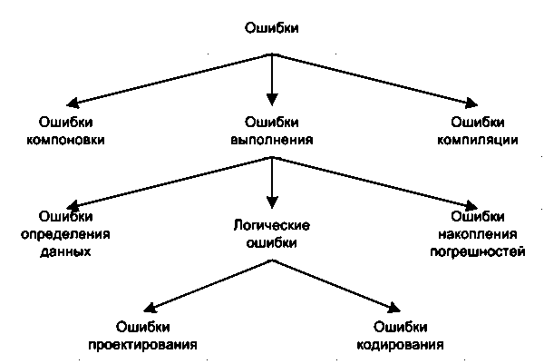

Рис. 5.1. Группы программных ошибок

Ошибки компиляции - это синтаксические ошибки, фиксируемые компилятором (транслятором, интерпретатором). Ошибки компиляции являются самыми простыми, так как синтаксис языка, как правило, строго формализован, и ошибки сопровождаются подробным комментарием с указанием местоположения ошибки. Чем лучше формализованы правила синтаксиса языка, тем больше ошибок из общего количества может обнаружить компилятор и, соответственно, меньше ошибок возникнет на следующих этапах. Ошибки компоновки - ошибки, обнаруженные компоновщиком (редактором связей) при объединении модулей программы. Ошибки компоновки связаны с проблемами, обнаруженными при разрешении внешних ссылок, Например, предусмотрено обращение к под- программе другого модуля, а при объединении модулей данная подпрограмма не найдена или не стыкуются списки параметров.

Стр. 67

Ошибки выполнения - ошибки, обнаруженные операционной системой, аппаратными средствами или пользователем при выполнении программы. Ошибки выполнения являются самыми непредсказуемыми. Некоторые из них обнаруживаются и документируются операционной системой. Они могут иметь разную природу и поэтому по-разному проявляться: появление сообщения об ошибке, например, деление на ноль, нарушение адресации, переполнение разрядов и т.п.; появление сообщения об ошибке, обнаруженной операционной системой, например при попытке записи на защищенные устройства памяти, при ссылке на отсутствующий файл и т.п.; «зависание» компьютера (иногда для продолжения работы необходима его перезагрузка); несовпадение полученных результатов с ожидаемыми. Причины ошибок выполнения очень разнообразны, а потому их сложно локализовать. Все возможные причины ошибок выполнения можно разделить на следующие группы: ошибки определения данных; логические ошибки; ошибки накопления погрешностей.

Ошибки определения данных (неверное определение исходных данных) возникают при выполнении операций ввода-вывода: ошибки передачи, ошибки преобразования, ошибки перезаписи, ошибки данных. Использование специальных технических средств и программирование с защитой от ошибок позволяют обнаружить и предотвратить только часть этих ошибок. Логические ошибки имеют разную природу и могут следовать из ошибок, допущенных при проектировании, например при выборе методов, разработке алгоритмов или определении структуры данных (классов), а могут быть непосредственно внесены при кодировании модуля. К ошибкам кодирования относятся: ошибки некорректного использования переменных, например неудачный выбор типов данных, использование переменных до их инициализации, использование индексов, выходящих за границы определения массивов, нарушения соответствия типов данных и т.п.; ошибки вычислений, например некорректная работа с переменными, некорректное преобразование типов данных в процессе вычислений и т.п.; ошибки взаимодействия модулей, т.е. межмодульного интерфейса, например нарушение типов и последовательности при передаче параметров, несоблюдение единства единиц измерения формальных и фактических параметров, нарушение области действия локальных и глобальных переменных.

Стр. 68

Возможны и другие ошибки кодирования, например неправильная реализация логики программы при кодировании, игнорирование особенностей или ограничений конкретного языка программирования. Ошибки накопления погрешностей возникают в результате накопления погрешностей результатов числовых вычислений, например при некорректном отбрасывании дробных цифр чисел, при некор- ректном использовании приближенных методов вычислений и т.п. Процесс отладки требует от разработчика глубоких знаний специфики среды и языка программирования, используемых технических средств, операционной системы. На сложность отладки оказывают влияние следующие факторы: опосредованное проявление ошибок; возможность взаимного влияния ошибок; возможность получения внешне одинаковых проявлений разных ошибок; стохастические ошибки, которые могут не проявиться от запуска к запуску; может аннулироваться или измениться внешнее проявление ошибок при внесении некоторых изменений в программу, например, при включении в программу диагностических фрагментов.

Отладка программы всегда предполагает обдумывание и логическое осмысление всей имеющейся информации об ошибке. Большинство ошибок можно обнаружить, тщательно анализируя текст программы и результаты тестирования. Методы отладки программного обеспечения можно классифицировать следующим образом [7]: метод ручного тестирования; метод индукции; метод дедукции; метод обратного прослеживания. Метод ручного тестирования - самый простой и естественный способ отладки программы. При обнаружении ошибки необходимо выполнить тестируемую программу вручную, используя тестовый набор, при работе с которыми была обнаружена ошибка. Метод эффективен, но не применим для больших программных систем и программ со сложными вычислениями. Этот метод часто используют как составную часть других методов отладки.

Стр. 69

Метод индукции предусматривает подробный анализ проявления ошибки. Это могут быть неверные результаты вычислений или сообщение об ошибке. Если компьютер просто «зависает», то место проявления ошибки в программном обеспечении определякт исходя из последних полученных результатов и действий пользователя. Полученную таким образом информацию можно изучить, просматривая соответствующий фрагмент программы. В результате выдвигаются гипотезы об ошибках, которые затем проверяются. Если гипотеза верна, то детализируют информацию об ошибке, иначе - выдвигают другую гипотезу. Если в результате изучения данных никаких гипотез не появляется, то необходима дополнительная информация об ошибке. Метод дедукции работает по следующему алгоритму. Сначала формируют множество причин, которые могли бы вызвать данное проявление ошибки. Затем, анализируя причины, исключают те, которые противоречат имеющимся данным. Если все причины исключены, то необходима дополнительная информация об ошибке и следует выполнить дополнительное тестирование исследуемого фрагмента. В противном случае наиболее вероятную гипотезу пытаются доказать. Если гипотеза объясняет полученные признаки ошибки, то ошибка найдена, иначе - проверяют следуюшую причину.

Рассмотрим категории программных ошибок, которые встречаются наиболее часто. Функциональные недостатки. Данные недостатки присущи программе, если она не делает того, что должна, выполняет одну из своих функций плохо или не полностью. Функции программы должны быть подробно описаны в ее спецификации, и именно на основе утвержденной спецификации тестировщик строит свою работу. Недостатки пользовательского интерфейса. Лучше всего оценить удобство и правильность работы пользовательского интерфейса может только пользователь в процессе работы с ним. Проверить это возможно с помощью прототипа программного обеспечения, на котором проводятся обкатка и согласование всех требований к пользовательскому интерфейсус дальнейшей фиксацией их в спецификации требований. После утверждения спецификации требований любые отклонения от нее или невыполнение последних являются ошибкой. Это в полной мере касается и пользовательского интерфейса.

Стр. 70

Недостаточная производительность. При разработке некоторого программного продукта очень важной его характеристикой может оказаться скорость работы, иногда этот критерий задается в требованиях заказчика к программному обеспечению. Недопустимо, если программа не удовлетворяет заданным в спецификации требований характеристикам. Это уже ошибка, которая должна быть обязательно устранена. Некорректная обработка ошибок. Правильно определив ошибку, программа должна выдать о ней сообщение. Отсутствие такого сообщения является ошибкой в работе программы. Некорректная обработка граничных условий. Существует много различных граничных ситуаций. Любой аспект работы программы, к которому применимы понятия «больше» или «меньше», «раньше» или «позже», «первый» или «последний», «короче» или «длиннее», обязательно должен быть проверен на границах диапазона. Внутри диапазонов программа может работать правильно, а на их границах могут происходить неожиданные ситуации, которые, в свою очередь, приводят к ошибкам в работе программного обеспечения.

Ошибки вычислений. К ошибкам вычислений относятся ошибки, вызванные неправильным выбором алгоритма вычислений, неправильными формулами либо формулами, неприменимыми к обраба- тываемым данным. Самыми распространенными среди ошибок вычислений являются ошибки округления. Ошибки управления потоком. По логике работы программы вслед за первым действием должно быть выполнено второе. Если вместо этого выполняется третье или четвертое действие, значит, в управлении потоком допущена ошибка. Ситуация гонок. Предположим, в системе ожидаются два события: Аи Б. Если первым наступит событие А, то выполнение программы продолжится, а если событие Б, то в работе программы произойдет сбой. Разработчики предполагают, что первым всегда должно быть событие А, и не ожидают, что Б может выиграть гонки и наступить раньше. Такова классическая ситуация гонок. Тестировать ситуации гонок довольно сложно. Наиболее типичны они для систем, где параллельно выполняются взаимодействующие процессы и потоки, а также для многопользовательских систем реального времени. Ошибки в таких системах трудно воспроизвести, и на их выявление обычно требуется очень много времени.

Перегрузки, Сбои в работе программы могут происходить из-за нехватки памяти или отсутствия других необходимых системных ресурсов. У каждой программы свои пределы, программа может не справляться с повышенными нагрузками, например со слишком большими объемами данных. Вопрос в том, соответствуютли реальные возможности программы, ее требования к ресурсам спецификации программы, и как она себя поведет при перегрузках. Некорректная работа с аппаратурой компьютера. Программы могут отправлять аппаратным устройствам неверные данные, игнорировать их сообщения об ошибках, пытаться использовать устройства. которые заняты или вообще отсутствуют. Даже если нужное устройство просто неисправно, программа должна понять это, а не «зависать» при попытке к нему обратиться.

Стр. 71